← Vamsi Gudipati · Portfolio

**Deep Reinforcement Learning for Flow Control: A Visual Guide**

Contents

# Deep reinforcement learning, from the loop to turbulence control

Seven lessons that build one idea at a time, each led by pictures: the learning loop, values, policy gradients, actor–critic on PDEs, the algorithm families and Gymnasium, surrogates for an airfoil, and multi-agent control of turbulence. Pick a lesson, or jump straight to a section.

I wrote this guide while working through the projects on this site, to have one place where every idea of deep reinforcement learning for fluid mechanics is drawn before it is written. It is meant for engineers who know some calculus, linear algebra and Python and have trained a neural network once; no reinforcement learning is assumed. Each lesson starts from a picture, adds one idea, and checks it with the results of an experiment that was actually run: a point mass, the heat, Burgers and Kuramoto–Sivashinsky equations, an airfoil in a gust with a CFD-built surrogate, and, in the last lesson, published studies of turbulence control. The airfoil experiments are written up in full as a flap controller trained inside a CFD-built surrogate and reduced-order models and a latent-space design search.

Vamsi Gudipati · October 2026

Agent, policy, actorEnvironment, physics, solverReward, cost, returnCritic, value functionsFailure, instability, pitfall

1

### The learning loop

After this lesson you can draw the agent and environment loop from memory, name every arrow on it, explain reward, return and discount, and describe the point mass, the first experiment of this guide, as a simulator with a reset and a step.

**18 sections**

1. Where this lesson sits
2. Why control needs a third kind of learning
3. An old idea: trial and error with a direction
4. The loop
5. The same loop in three costumes
6. The point mass, piece by piece
7. Feel the plant: push it yourself
8. The environment is a piece of software with two methods
9. How an episode ends, and where it starts
10. Reward scores a step, return scores what follows
11. The discount factor sets how far ahead the agent looks
12. The reward is the only channel for the goal
13. Exploring while training, committing when done
14. Three difficulties built into the loop
15. When is the learning worth it?
16. Connect the dots
17. Check yourself
18. Next

2

### Values and the Bellman equations

After this lesson you can read the Markov decision process, the value functions V and Q, the advantage and both Bellman equations as pictures, and you can say why they split the algorithms into two families.

**15 sections**

1. One episode gives one return. A state deserves an average.
2. The formal stage: a Markov decision process
3. The Markov property: the present state is enough
4. Deterministic solver, random episodes
5. Three numbers for one state: V, Q and the advantage
6. The Bellman expectation equation: a state's value from its successors
7. The Bellman optimality equation: replace the average by a maximum
8. Watch the values spread: value iteration, one sweep at a time
9. Two ways to organize the sweeps: policy iteration and value iteration
10. Why Q is the more useful table when the model is unknown
11. The solver is the model, and nobody hands it to the agent
12. The fork in the road: two routes and their combination
13. Preview: how the advantage will steer the policy
14. Connect the dots
15. Check yourself

3

### Policy gradients with REINFORCE

After this lesson you can explain, with pictures, how returns nudge a neural network policy, why the simplest way of doing it is noisy, and how the learned controller is judged against the classical PD and LQR controllers.

**17 sections**

1. Before training a network, build the classical yardsticks
2. Try both controllers on the point mass
3. What each controller needs and what it promises
4. The anatomy of the learner: which component sits where
5. The policy: a network that places a bell curve over the force
6. Same state, different pushes: σ is the exploration knob
7. The log-probability: how strongly the policy backed its own action
8. The REINFORCE principle: the return decides which actions to back
9. Watch the mechanism: one state, many samples, repeated updates
10. One training iteration, message by message
11. Why the estimate is noisy, and what the fixes are
12. What happened in training
13. What a control law looks like: force as a map over the state
14. Judging the result: five rules, then the numbers
15. What this experiment shows, and its pitfalls
16. Connect the dots
17. Check yourself

4

### Actor–critic on PDEs: heat, Burgers, Kuramoto–Sivashinsky

One learner is carried up three equations of rising difficulty. After this lesson you can explain the actor–critic update, how a solver becomes an environment, why a target must be reachable, how the classical reference changes with the physics, and where the learned controller ends above or below it, with the numbers from the training runs shown here.

**18 sections**

1. One learner, four rungs of physics
2. What is wrong with weighting by the raw return?
3. Two networks: one acts, one judges
4. Inside the actor and the critic
5. One batched update, stage by stage
6. How a PDE solver becomes an environment
7. Environment 1: the heat equation, live
8. Why the target must be reachable
9. Environment 2: Burgers, where the field carries itself
10. Environment 3: Kuramoto–Sivashinsky, where long waves grow
11. Where episodes start, and which starts are kept for testing
12. The classical reference changes with the physics
13. Results: how training went
14. Results: learned controller against the classical reference
15. How to judge a learned controller
16. Connect the dots
17. Check yourself
18. Next

5

### The algorithm families and Gymnasium

After this lesson you can place DQN, DDPG, TD3 and PPO on one map, draw the trick each one relies on, say when reusing data matters for an expensive simulation, and read or write a Gymnasium environment and the few library lines that train on it.

**15 sections**

1. A map of the algorithm families
2. Q-learning: move an estimate toward a target
3. DQN: the table becomes a network, with two stabilisers
4. Why the max breaks, and how DDPG removes it
5. PPO: limit how far one update may move the policy
6. Three families, one loop
7. On-policy or off-policy is a question about data
8. Which algorithm for my problem?
9. Gymnasium: one interface between physics and learner
10. Training with Stable-Baselines3 in a few lines
11. The Gymnasium point-mass experiment: the same plant through the library
12. The Gymnasium KS experiment: suppressing chaos with PPO
13. Eight variations: where the result stops holding
14. Connect the dots
15. Check yourself

6

### Airfoil control: reduced models and CFD surrogates

What to put inside the environment when the real simulator is too slow to train on. After this lesson you can draw the ladder of models from a three-equation airfoil to full CFD, explain how a surrogate is built, validated and plugged into the loop, and say where it can fool the agent.

**19 sections**

1. What if every step is a CFD run?
2. The fidelity ladder
3. The control problem: hold the lift through a gust
4. The 0-D model: one static law and two lags
5. The same problem as observation, action and reward
6. Feel it: fly the gust yourself
7. Training on the 0-D model, and what the agent learned
8. Seven what-ifs on the cheap model
9. Step 2 of the ladder: building a surrogate from RANS data
10. How good is the surrogate, and where?
11. Plugging the model into the loop: swap one box
12. Two networks, two kinds of learning
13. What the surrogate environment taught the agent
14. The danger zone: where the agent takes the surrogate
15. Step 3 of the ladder: a field model in the same environment
16. Is this transfer learning?
17. The working rule: train cheap, test on something better, know your range
18. Connect the dots
19. Check yourself

7

### DRL for turbulence and flow control

The loop from Lesson 1 is now wrapped around a direct numerical simulation of turbulence. After this lesson you can explain how it scales to a whole wall through many identical agents, how a study is judged, and how the reward decides which physics the agent attacks.

**17 sections**

1. The same loop, now with a DNS inside
2. The environment: a turbulent open channel
3. The yardstick: opposition control
4. One agent for the whole wall does not scale. Many identical agents do.
5. How the Fortran solver and the Python learner talk
6. What the agent achieved, and how it differs from the baseline
7. Does the saving survive the cost of actuation?
8. The reward decides which physics the agent attacks
9. Separation bubbles: learning the forcing a human would tune by hand
10. Rayleigh–Bénard convection: single agent against multi-agent, same problem
11. Cylinder wakes: the strategy changes when the physics changes
12. All the studies on one chart
13. Five questions to ask of any flow-control study
14. Common questions, takeaways, and the papers
15. Connect the dots: this lesson
16. The whole guide on one page
17. Check yourself

Every lesson opens with a bridge from the previous one and ends with a concept map, a short quiz and a bridge to the next. Figures with buttons and sliders are live: press Step, drag, or click the boxes of an anatomy loop to see what each component holds.

Lesson 1 of 7 · Agent, environment, reward · point mass

# The learning loop

After this lesson you can draw the agent and environment loop from memory, name every arrow on it, explain reward, return and discount, and describe the point mass, the first experiment of this guide, as a simulator with a reset and a step.

## Where this lesson sits

[figure not shown]

The path through this guide. Each step adds one idea on top of the previous one. The loop from this lesson is still there, unchanged, on step 7.

This lesson has no learning algorithm in it yet. It sets up the stage on which every algorithm of the guide plays: something that acts, something that reacts, and one number that says how well it went.

## Why control needs a third kind of learning

[figure not shown]

The three ways a machine can learn, shown with a bag of red and blue balls. In the first two a fixed dataset does the teaching. In the third there is no dataset at all, only a system that answers back.

A network trained by supervised learning learns from simulations that were run beforehand and saved. Control cannot work that way, because the quality of an action only shows in how the system responds to it. Something must react to the controller while it learns, so an equation has to be solved inside the training loop.

**In practice**

To learn control, something must be controlled, and that means one equation to solve. Solving Navier–Stokes inside a training loop is too expensive for a first experiment, so the guide climbs through model equations: a point mass, the heat equation, Burgers, Kuramoto–Sivashinsky. This lesson uses the first one.

## An old idea: trial and error with a direction

[figure not shown]

Top: the history in four stages. Bottom: a robot rewarded only for distance. Nobody shows it how to run; it crawls, rolls, stands up and falls until running is what pays best.

Reinforcement learning (RL) goes back to the beginnings of artificial intelligence in the 1950s, with Bellman as a key contributor. The idea is decision-making through interaction: try an action, see the score, prefer what scored well. Its fields of use include robotics, finance, games such as AlphaGo, and fluid mechanics.

**Intuition**

The objective is to maximize the reward, and the agent learns by trial and error. Because the reward points toward a goal, it is a very smart trial and error: the trials have a direction.

## The loop

One turn is one time step k. The agent holds the state, picks an action, and the environment answers with the next state and a reward. The numbers are the point-mass environment of this lesson pushed with a constant force of 0.5 from x = −1.5.

The agent is the thing that learns; in this guide it is a neural network. The environment is everything else: the physics, the solver, the sensors. Each action changes the state, which is the agent's observation of the system, and produces a reward, a scalar measure of the quality of the action.

**State**What the controller observes: a position and a velocity, or a discretized field.

**Action**What the controller changes: a force, or actuator amplitudes.

**Reward**How good the action was: one number per step.

**Policy**How actions are selected from the state. Written π(a | s).

**Key idea**

These four words carry the whole vocabulary. Remember exactly these names, because every experiment in this guide is built from them.

### What lives inside the two boxes

The loop above is the same in every lesson. What changes is what sits inside the two boxes. The drawing below opens them for the point mass: six slots inside the agent, five inside the environment, and the three arrows with the number of values each one carries. The same drawing returns in every later lesson with more slots switched on.

[figure not shown]

Click any box (or focus it and press Enter) to see what it holds in this lesson, what goes in and out of it, and the code it maps to.

The loop with its components. Thick border: introduced in this lesson. Dashed and faded: not used yet, with the lesson that switches it on. Solid arrows carry data; the dashed grey arrows are the weight updates that arrive with learning in Lesson 3. The numbers on the three loop arrows are the sizes of what travels round the loop for the point mass.

In this lesson the agent is almost empty. Its policy is any rule from state to action, its memory is the record of one episode, and nothing in it changes between episodes. The environment, on the other hand, is complete, and the next sections build it piece by piece. Lesson 3 fills the agent side: the policy becomes a network, and exploration, the update rule and the evaluation switch come with it. Lesson 3 also opens the network itself.

## The same loop in three costumes

[figure not shown]

Small multiples of one drawing. Blue goes down (action), green and amber come back up (state and reward). Only the text changes, from two numbers and one force to a direct numerical simulation (DNS) of wall turbulence.

This is a ladder in which the physics becomes harder while the control vocabulary stays the same. In the channel the actions are blowing and suction at the wall, the state is the velocity fluctuation above the wall, and the reward is the relative reduction of the wall shear stress. Lessons 4 and 7 open the middle and the right panel; for the rest of this lesson the left one is enough.

## The point mass, piece by piece

The point-mass experiment, the first experiment of this guide, uses the smallest possible plant. A unit mass slides on a line with some damping. The agent pushes it with a bounded force and must park it at the target position x★ = 1.

The whole environment. Two numbers describe it at any instant (error and velocity), one number drives it (the force), and one number scores it (the reward).

x<sub>k+1</sub> = x<sub>k</sub> + Δt·v<sub>k</sub> v<sub>k+1</sub> = v<sub>k</sub> + Δt·(F<sub>k</sub> − c·v<sub>k</sub>) with Δt = 0.1, c = 0.2, 80 steps

**State**Position error and velocity.`s = (x − x★, v)`

**Action**One bounded force.`a = F ∈ [−1, 1]`

**Transition**One explicit Euler step of the two equations above.`s′ = A·s + B·F`

**Reward**Minus a cost: miss distance plus effort.`r = −[(x − x★)² + 0.01·F²]`

In CFD terms this is time stepping: the environment is a two-equation solver with explicit Euler, and one control step is one solver step. The best possible reward is zero, sitting on the target with no force. Every other situation scores negative, so "maximize reward" means get there, stay there, and do not waste effort.

The state stores the error x − x★ rather than x itself. This is on purpose: the target then always sits at zero error, so the same policy can serve another target later.

## Feel the plant: push it yourself

Before any network, be the controller. The simulation below runs exactly the update above (Δt = 0.1, c = 0.2, x★ = 1, 80 steps, reward with weight 0.01 on F²). It opens on a simple demonstration: a constant force of +0.5 from x = −1.5.

force F +0.50

start**x = −1.50, v = 0.00**

after 80 steps

sum of rewards

verdict

The point-mass environment, simulated live with the equations and parameters above. Random starts are drawn as in training: position in [−2, 2], velocity in [−0.25, 0.25].

Three things to try. First, the constant force: it carries the mass to the target and straight past it, and the summed reward ends worse than if you had not pushed at all (set F to 0 to compare). Second, "Push, then brake": tune the two sliders until the mass parks at x = 1, then press "New random start" and watch the same schedule miss. Third, the feedback rule, which reads the state at every step and parks the mass from any start.

**Key idea**

In one sentence: a constant open-loop force moves the mass toward the target but does not know when to brake, which is why the policy must use both position error and velocity. A schedule fixed in advance is open-loop control. A rule from state to action is feedback, and a policy is exactly such a rule.

The feedback rule in the third button is a proportional-derivative controller with gains 1.2 and 1.4. Lesson 3 treats it properly, next to the linear-quadratic regulator. Here it only shows what the agent has to discover by itself: push when far, brake when fast. From the standard start a well-tuned push-and-brake can score a little better than this rule (about −79 against −81), but it cannot repeat that from the next start.

## The environment is a piece of software with two methods

[figure not shown]

Eight messages. Press the button to follow them one at a time.

Read it top to bottom like a solver log. Solid arrows are calls, dashed arrows are what comes back. The physics lives inside the environment; the learning lives outside it.

An equation becomes an environment once it can be advanced by one control interval. `reset()` starts an episode and returns the first observation. `step(action)` applies one action, advances the dynamics by one control interval and returns five things: the new observation, the reward, a `terminated` flag, a `truncated` flag and a dictionary of diagnostics.

```
def step(self, action):
    force = float(np.clip(np.asarray(action).reshape(-1)[0], -1.0, 1.0))
    self.state = (self.A @ self.state + self.B[:, 0] * force).astype(np.float32)
    self.step_count += 1
    position_error, velocity = self.state
    reward = -(position_error**2 + self.effort_weight * force**2)
    terminated = False
    truncated = self.step_count >= self.horizon
    info = {"position": float(position_error + self.target),
            "velocity": float(velocity), "force": force}
    return (self.state.copy(), float(reward), terminated, truncated, info)
```

This is the `step` method of the `PointMassEnv` environment. Every line maps to a box you have already seen: clip the force, one Euler step as a matrix update, the reward, the two flags.

[figure not shown]

Click a box or a numbered code line to pair them up and see what that part receives and returns.

One call of `step()` taken apart. Left: the four environment components from the anatomy figure plus the clip in front of them, with the size of every value that moves between them. Right: the same code as above, each line tagged with the component it belongs to. A = (1, 0.1; 0, 0.98) and B = (0; 0.1) are the two Euler equations written as one matrix update.

Four small functions share the work, and only the plant has a memory of its own: the two numbers in `self.state`. The observation here is a copy of exactly those two numbers, which is the simplest case; later environments measure less than the plant holds, and a variation of this experiment hides the velocity to see what that costs. The reward and the flags are computed fresh at every call from the state and the force. Nothing inside `step()` ever learns, and no gradient ever flows through it: from Lesson 3 on, learning happens outside, from the numbers it returns.

**In practice**

The environment is written by hand, but it follows the reset-and-step convention of the Gymnasium library on purpose. It is worth building one yourself once, because in a real problem the library may not be the right tool and you may have to do everything yourself. Lesson 5 moves the same point mass into Gymnasium.

## How an episode ends, and where it starts

[figure not shown]

Left: termination means a physical or task condition ended the episode; truncation means an external limit did. Right: every training episode of the point-mass experiment starts somewhere in this box (the dots are illustrative draws).

The distinction matters later. A truncated episode was cut by the clock, so the story would have continued; a terminated one really ended. The point-mass environment sets `terminated = False` always and `truncated = True` once the step count reaches the horizon of 80.

Random initial conditions keep the agent from memorizing one trajectory. With a single fixed start it could learn one sequence of pushes, the "Push, then brake" schedule you tuned above. With starts spread over the box it must learn a feedback law that works from anywhere in it.

**In practice**

The environment is created with a seed so that the random numbers are repeatable: the starts differ from episode to episode, but a rerun draws the same sequence and you can compare runs.

## Reward scores a step, return scores what follows

[figure not shown]

An episode is one complete attempt, from a start to the step limit. Training is hundreds or thousands of them; for flow control each one is a short simulation in which the agent gathers experience.

A single reward measures only the immediate quality of one step. But a push now changes every later state, as the overshoot in the simulation above showed. So an action is judged by the **return**: the sum of the rewards from that step to the end of the episode, with later rewards counted a little less.

G<sub>t</sub> = r<sub>t</sub> + γ·r<sub>t+1</sub> + γ²·r<sub>t+2</sub> + … = r<sub>t</sub> + γ·G<sub>t+1</sub>

[figure not shown]

All five returns shown. Press to rebuild them from the right.

The recursion at work on made-up numbers. Each return is its own reward plus 0.9 times the return to its right, so one backward pass gives all of them. The point-mass experiment computes the 80 returns of an episode the same way.

Read the bottom row from the left: G₀ = −7.34 is the score of the whole episode as seen from its first action, while G₃ = −1 only sees the last two steps. Early actions carry responsibility for everything that follows them. That is the right bookkeeping for a plant with inertia, where a push at step 5 decides where the mass is at step 40.

## The discount factor sets how far ahead the agent looks

discount γ 0.95

[figure not shown]

Move the slider: the blue curve is γᵏ for the chosen γ and the blue dot is its weight 20 steps ahead. The two rings are two reference values, 0.99²⁰ ≈ 0.82 and 0.95²⁰ ≈ 0.36.

With γ near zero the controller looks only at the next step. Near one it weighs every step to the end of the episode and so considers long-term consequences. A rule of thumb: a discount factor near 0.99 makes the policy weigh long-term consequences, and lowering it to 0.95 makes the network focus on the next 10 to 20 steps.

**The money picture**

An analogy from finance: with γ = 0.9, a bill of 100 received one year later is worth 90 today. A reward that arrives later is worth less now, and γ is the exchange rate per step.

**Why this is not a detail**

The point-mass training run of Lesson 3 uses γ = 0.95 rather than 0.99. A good push on the point mass pays off tens of steps later, which a short-sighted agent hardly sees. Lesson 3 shows what that did to training.

The agent's whole objective in one sentence: find the policy whose *expected* return is as large as possible, where the expectation covers the random actions and the random starts. Every algorithm in the later lessons is a different way of chasing that one number.

## The reward is the only channel for the goal

[figure not shown]

A schematic of the pitfall described below, drawn along one actuator amplitude a. Solid amber is the tracking cost, dashed is the effort cost. Left: both are lowest at the holding action a★. Right: effort is lowest at zero, so their sum is lowest somewhere short of a★.

The reward is the only channel through which the objective reaches the policy, so its form decides what is learned. All four model environments of this guide (point mass, heat equation, Burgers, Kuramoto–Sivashinsky) use the same recipe, a negative cost with two parts: a tracking term (how far from the target) and an effort term (how hard the actuators work), weighted by λ. For the point mass λ = 0.01.

r<sub>k</sub> = −[ (1/n<sub>s</sub>)·‖s<sub>k+1</sub> − s★‖² + λ·‖a<sub>k</sub> − a★‖² ] point mass: r = −[(x − x★)² + 0.01·F²]

**Pitfall**

Some targets need a nonzero action just to be held. The heated rod of the heat-equation experiment (Lesson 4) keeps its target profile only while the heaters stay at a★ = (0.55, 0.35). Penalizing ‖a‖² there rewards the controller for switching off the very forcing that holds the target. Penalize the deviation ‖a − a★‖². The point mass escapes the problem because holding x = 1 needs no force, so a★ = 0.

The reward need not measure the objective directly. In the research of Lesson 7, a controller of wall turbulence was rewarded for suppressing the flow regions that an explainability method (SHAP) marked as most important, instead of for drag reduction itself. Lesson 7 returns to what that bought.

## Exploring while training, committing when done

The policy π(a | s) is a probability distribution over actions. Sampling from it is how the agent explores during training; taking its most probable action is how the finished controller behaves.

The agent learns by trying many different actions, stochastically, and training makes those with the highest return more probable. This is the balance between **exploration** (trying something new, which may be better) and **exploitation** (repeating what already works). Once training ends the parameters are frozen and the policy is evaluated deterministically: for a given state it always takes the same action.

The word "deep" means that the policy is a deep neural network. Because a network is nonlinear, it has an advantage precisely when the problem is difficult. How the network's weights are actually moved toward better actions is the policy gradient of Lesson 3.

## Three difficulties built into the loop

[figure not shown]

Three difficulties. The numbers in the right panel are the state sizes of the experiments in this guide (point mass 2, heat and Burgers 39, Kuramoto–Sivashinsky 64); the box sizes are schematic.

First, the value of each state is not known in advance, which is why RL is trial and error in the first place. Second, exploration and exploitation must be balanced, and no rule settles that for every problem. Third, exploring costs simulation time, and for high-dimensional states and actions the learned quantities must be approximated with neural networks.

Each difficulty is answered by a later lesson. Lesson 2 defines "the value of a state" precisely. Lessons 3 to 5 show how different algorithms explore and how they reuse expensive experience. Lesson 7 shows what makes exploration affordable in a turbulent channel.

## When is the learning worth it?

[figure not shown]

A teaser for the comparison of controllers in Lessons 3 and 4. On the linear point mass the classical side should win. The six boxes are what pushes a problem to the right.

Learning does not beat classical control everywhere. For a known linear system with a quadratic objective, a classical regulator should normally be more accurate, more reliable and cheaper, and the point mass is such a system. It is a toy: it is there to show how the machinery works. Lessons 3 and 4 put the learned controller next to the proportional-derivative (PD) controller and the linear-quadratic regulator (LQR) on the same test cases.

## Connect the dots

[figure not shown]

The vocabulary of this lesson on one page. If you can redraw this map and the loop from memory, you have what the next six lessons assume.

Everything hangs on the centre. The agent and the environment are the two boxes of the loop, the reward is the arrow that carries the goal, and the return is how rewards are added up along an episode. Exploration is what the agent does with the loop while it does not yet know better.

## Check yourself

**Why can't a controller be trained on a fixed dataset, the way a supervised network is?**

Because nobody has the right action for each state, and the quality of an action only shows in how the system responds to it. Something must react to the controller while it learns, so the dataset is replaced by an environment: a simulation or an experiment.

**Draw the loop and name its three arrows for the point mass.**

Agent to environment: the action, one force F in [−1, 1]. Environment to agent: the next state (x − x★, v) and the reward −[(x − x★)² + 0.01·F²]. One turn is one explicit Euler step of Δt = 0.1.

**A constant force of +0.5 from x = −1.5 ends with a worse summed reward than no force at all. Why, and what does a good controller need?**

The open-loop force carries the mass through the target and far beyond it, because it does not know when to brake. Braking in time needs the velocity as well as the position error, which is why the state holds both and the policy must be a feedback rule.

**Name the four components inside the environment box and say which of the five values returned by step() each one produces.**

The plant (solver) advances the state s = (x − x★, v) by one Euler step and keeps it; it returns nothing directly. The observation returns a copy of that state, sₖ₊₁ (2 numbers). The reward function returns rₖ = −[(x − x★)² + 0.01·F²] (1 number). The end check returns terminated (always False) and truncated (True once the step count reaches 80). The info dictionary only carries diagnostics for plots.

**Why would it be wrong to mark the end of every 80-step point-mass episode as terminated?**

Nothing physical ended the episode; an outside step limit did. That is truncation. Termination is reserved for a physical or task condition, and the point-mass environment never sets it.

**You lower γ from 0.99 to 0.95. What changes?**

The agent becomes near-sighted. A reward 20 steps ahead drops from a weight of about 0.82 to about 0.36, so the network focuses on roughly the next 10 to 20 steps. On a plant where a good push pays off tens of steps later, that hides much of the consequence of each action.

**The heaters must stay at a★ = (0.55, 0.35) to hold the target temperature profile. What goes wrong if the reward penalizes ‖a‖²?**

The effort term is then lowest at a = 0, so the reward encourages the controller to switch off the forcing that holds the target. The best reward moves off the target. Penalizing ‖a − a★‖² puts both terms at zero in the same place.

## Next

**Into Lesson 2**

The return scores one episode after it has been played. Lesson 2 asks the sharper question: how good is it to *be* in a state, or to take a given action there, before the episode is played? The answer gives the value functions V and Q, the Markov property they rest on, and the Bellman equations, which grow directly out of the recursion G<sub>t</sub> = r<sub>t</sub> + γ·G<sub>t+1</sub> you just worked by hand.

Lesson 2 of 7 · Value functions, Markov decision processes, Bellman equations

# Values and the Bellman equations

After this lesson you can read the Markov decision process, the value functions V and Q, the advantage and both Bellman equations as pictures, and you can say why they split the algorithms into two families.

**From Lesson 1**

The return G<sub>t</sub> = r<sub>t</sub> + γ·G<sub>t+1</sub> scores what followed an action in *one* episode, and the goal is the policy with the largest expected return. This lesson asks the next question: how good is it to *be* in a state, or to take a given action there, on average over many episodes?

## One episode gives one return. A state deserves an average.

[figure not shown]

Each blue line is one episode of the point mass from the same state (x = 0, v = 0), under the same noisy policy; the dashed line is the target. Each amber dot is that episode's return. The violet line is their mean, and it settles as episodes accumulate. Environment and reward are those of the point-mass experiment, in which a force steers a damped mass to a target position (Δt = 0.1, damping 0.2, γ = 0.95, 80 steps); the policy is an illustration: a PD law plus Gaussian noise of 0.5, squashed by tanh.

The policy samples its actions, so the same start gives a different trajectory and a different return each time. No single return is "the" score of that starting state. The stable quantity is the mean of all of them, and that mean is called the value of the state.

V<sup>π</sup>(s) = E<sub>π</sub>[ G<sub>t</sub> | s<sub>t</sub> = s ]

Read it aloud as "the return you expect from state s if policy π stays in control". E<sub>π</sub> is the average over everything random in the episodes that π generates.

**Pitfall**

A value always belongs to a policy. The superscript π is part of the definition: change the policy and the same state has a different value. "The value of this state" without saying which policy is controlling has no meaning.

## The formal stage: a Markov decision process

To average over "everything that can follow", you need a precise description of what can follow. That description is the Markov decision process (MDP): the tuple (S, A, P, R) of states, actions, a transition function and a reward function.

[figure not shown]

An illustration with invented numbers: a flow that is either separated or attached, and a jet that is on or off. Read one path: in "Separated" with "jet on", the flow reattaches with probability 0.8 and stays separated with probability 0.2. Those numbers on the green arrows are the transition function.

P(s′ | s, a) = Pr( s<sub>t+1</sub> = s′ | s<sub>t</sub> = s, a<sub>t</sub> = a ) r<sub>t</sub> = R(s<sub>t</sub>, a<sub>t</sub>, s<sub>t+1</sub>)

**S, the state space**All states the system can be in. Here two; for the heat-equation experiment, every possible temperature field on the grid.

**A, the action space**All actions the agent may take. Here two; in the experiments of this guide a continuous force or actuator amplitude.

**P, the transition function**The probability that action a in state s leads to s′. It is the physics.

**R, the reward function**The number assigned to each transition (s, a, s′). It is the objective.

The blue arrows are the agent's part: the policy π(a | s) decides which action node is entered. The green arrows are the environment's part. Every expectation in this lesson is an average over those two kinds of arrow, blue then green.

**In practice**

Before any learning, the control problem must be expressed as a Markov decision process, defined by a state, an action, a transition rule and a reward. These four things have to be defined every time a problem like this is set up, as they are for the heat-equation experiment.

## The Markov property: the present state is enough

[figure not shown]

Top: in an MDP the next state depends on the present state and action only. Bottom: a one-step time-marching scheme works the same way. Give it the current field and the forcing and it produces the next field, without asking how the flow got there.

This is the **Markov property**, and it sits inside the conditioning of P(s′ | s, a): only s and a appear, no earlier history. In CFD terms, it is what makes restarting a simulation from a saved field possible. One honest caveat from the solver side: a multi-step scheme that stores earlier time levels needs those levels too, so there the "state" is the current field together with the stored ones.

**Intuition**

For the heat equation the state contains all the information required to compute the next temperature field: what happens at step k+1 is fixed by the state and the action at step k, and does not depend on whatever happened before.

### Where the property breaks: sensors see only part of the state

[figure not shown]

A schematic. Three sensors (amber dots) sample two different fields at the same points and report identical numbers. The two fields will evolve differently, so from the sensor readings alone the future is no longer determined by "the present".

This matters in practice: the measured state of a real system is often only a partial observation of a higher-dimensional state. It returns in the channel-flow research, where the agent sees one plane of the flow and the authors note that the system is then "not entirely Markovian" (Lesson 7). The Kuramoto–Sivashinsky (KS) experiment with only eight sensor points tests exactly this limit; Lesson 5 covers it.

## Deterministic solver, random episodes

[figure not shown]

Top left: a solver step is a deterministic map, so P puts all its probability on one next state. Top right: the general MDP allows several outcomes. Bottom: in the experiments of this guide the two random ingredients are the start drawn by reset and the action sampled by the policy.

The MDP is written with probabilities so that it also covers noisy systems. The point-mass, heat-equation, Burgers and Kuramoto–Sivashinsky environments of this guide advance by a numerical time step, which returns the same next state for the same state and action. The expectation in the objective therefore covers the random actions and the random initial conditions.

## Three numbers for one state: V, Q and the advantage

V judges a state. To judge an *action*, fix the first action and let the policy take over afterwards. That gives the action-value function, or Q function. The difference between the two is the advantage.

V<sup>π</sup>(s) = E<sub>π</sub>[G<sub>t</sub> | s<sub>t</sub>=s] Q<sup>π</sup>(s,a) = E<sub>π</sub>[G<sub>t</sub> | s<sub>t</sub>=s, a<sub>t</sub>=a] A<sup>π</sup>(s,a) = Q<sup>π</sup>(s,a) − V<sup>π</sup>(s)

[figure not shown]

probability the policy gives to a₃ 0.34 Σ π·A = 0.00

An illustration with invented numbers. The bars are Q for three actions in one state. The dashed line is V, the mean of the bars weighted by the policy's probabilities. Each arrow is an advantage: the signed gap from V to a bar. Move the slider: as the policy puts more weight on the best action, V climbs toward the tallest bar.

V<sup>π</sup>(s) = Σ<sub>a</sub> π(a|s) · Q<sup>π</sup>(s,a) ⇒ Σ<sub>a</sub> π(a|s) · A<sup>π</sup>(s,a) = 0

Averaging Q over the policy's own actions gives back V. So the advantages, weighted the same way, always sum to zero: the readout under the chart stays at 0.00 wherever the slider is. The advantage answers a relative question, "is this action better or worse than what the policy would do on average here?", and that relative question is the one the learning algorithms of Lessons 3 and 4 need.

### Where V and Q live in the loop

[figure not shown]

Click a slot (or focus it and press Enter) to read what it holds in this lesson, its input and output, and the code it corresponds to.

The loop of the point-mass experiment with its components. Blue is the agent, green the environment; a thick violet frame marks what is new in this lesson, dashed and faded what is not used yet. New here is the critic: an estimate of V or Q, a table for the grid, a network from Lesson 4 on. It reads states, rewards and next states from Memory, and the greedy policy reads its Q values. The dashed slot at the bottom of the agent is a model of the environment, P and R; it stays empty in a model-free method, which is every method in this guide.

The value functions are not a new box in the environment. They sit inside the agent, next to the policy, and they are built from what the loop delivers: the observations and rewards that pass through Memory. That placement is the anatomy of every actor–critic method later in the guide; only the table inside the critic slot becomes a network.

## The Bellman expectation equation: a state's value from its successors

Computing V from its definition would mean summing rewards over every possible future. The recursion of the return, G<sub>t</sub> = r<sub>t</sub> + γ·G<sub>t+1</sub>, removes that need: take one step, collect one reward, and what remains is the value of where you landed.

[figure not shown]

A backup diagram. Read it top to bottom as "what can happen next", and bottom to top as the computation: the leaves send their values back up, each weighted by the probability of its branch.

V<sup>π</sup>(s) = Σ<sub>a</sub> π(a|s) Σ<sub>s′</sub> P(s′|s,a) [ R(s,a,s′) + γ·V<sup>π</sup>(s′) ]

1. π(a|s): average over the actions the policy might take (blue branches).
2. P(s′|s,a): for each action, average over where the environment might send you (green branches).
3. R + γ·V<sup>π</sup>(s′): on each branch, the reward of that one step plus the discounted value of the landing state.

What this achieves: the equation replaces a sum over all future time steps by a relation between the value of a state and the values of its successors, which is what makes the value computable. The same recursion holds for Q, with the action fixed at the top and the policy averaging at the next state.

### The same shape as an iterative linear solver

[figure not shown]

Left: a Jacobi sweep replaces each unknown by a weighted mean of its neighbours' old values. Right: a policy-evaluation sweep replaces each state's value by a weighted mean over its successors, plus the reward on the way.

For a fixed policy the Bellman expectation equation is a linear system: one equation per state, each coupling a state to its successors. Iterating it from any initial guess converges to V<sup>π</sup>; this is called **policy evaluation**, and it is a fixed-point iteration of the same kind as Jacobi sweeps. The analogy has limits you should keep in mind: the "neighbours" are successor states under the dynamics, which need not be near each other in physical space, and it is the discount γ < 1 that makes each sweep shrink the error.

## The Bellman optimality equation: replace the average by a maximum

[figure not shown]

An illustration: the same three branch values are used in both panels only to show the operation. Under a policy, the branches are averaged with the policy's weights. For the best achievable value, the best branch is taken.

Define the best achievable values as V*(s) = max<sub>π</sub> V<sup>π</sup>(s) and Q*(s,a) = max<sub>π</sub> Q<sup>π</sup>(s,a). They satisfy the same recursion, with the average over actions replaced by a maximum.

V*(s) = max<sub>a</sub> Σ<sub>s′</sub> P(s′|s,a) [ R(s,a,s′) + γ·V*(s′) ]  
Q*(s,a) = Σ<sub>s′</sub> P(s′|s,a) [ R(s,a,s′) + γ·max<sub>a′</sub> Q*(s′,a′) ] π*(s) = argmax<sub>a</sub> Q*(s,a)

**Key idea**

Bellman's principle of optimality: a multi-step policy that is optimal overall must be optimal from every state it reaches. So the best long plan can be assembled from best single steps, provided each step is judged by reward plus the optimal value of where it lands. If Q* is known, the best action in a state is the one with the largest Q*.

**Intuition**

Reinforcement learning goes back to the 1950s, the very beginning of artificial intelligence, and Bellman founded this part of it. "Deep" reinforcement learning is the same idea with a deep neural network doing the learning.

## Watch the values spread: value iteration, one sweep at a time

A small grid makes both Bellman equations visible. The agent moves one cell up, down, left or right; a move into a wall or the edge leaves it where it is. Entering the goal pays +1, entering the pit pays −1, both end the episode, and every other move pays 0.

γ 0.90

An illustration. Each press of Sweep applies the Bellman update once to every cell, using the values of the previous sweep (a Jacobi-style sweep). The figure opens after three sweeps. In "max" mode the numbers converge to V*; in "random policy" mode the four moves are equally likely and the numbers converge to V<sup>π</sup> of that policy. The blue arrows point to the neighbour with the best reward-plus-value. The chart on the right is the residual history, on a log scale.

Press Reset, then Sweep several times. After one sweep only the cell next to the goal knows anything. Each further sweep carries the information one cell further back, multiplied by γ, exactly as the backup diagram says: a cell's value is built from its successors' values. Lower γ and the values fade faster with distance; the arrows, however, still find the goal.

Now switch to the random policy. The same cells get much lower values, negative near the pit, because a policy that stumbles around often falls in. That is the pitfall from the first section made visible: value is a property of a state *under a policy*. With the arrows on in this mode you see the greedy policy with respect to V<sup>π</sup>, which is already far better than the random policy that produced those values.

Look at the residual chart too. Under the random policy the largest change falls geometrically, like the residual of a linear solver. This grid has 19 cells to solve for and a known model; flow problems have continuous states and no table can hold their values, which is where the neural networks of the later lessons come in.

## Two ways to organize the sweeps: policy iteration and value iteration

[figure not shown]

Left: policy iteration alternates a full evaluation of the current policy with a greedy improvement, until the policy stops changing. Right: value iteration merges the two steps through the maximum in the optimality equation, and reads the policy off at the end. With a stochastic environment the bracket carries the sum over s′ weighted by P.

You ran both in the grid. "Evaluate the random policy" followed by turning the arrows on is one round of the left chart: evaluate, then improve greedily. "Max" mode is the right chart. Both are **dynamic programming**: they sweep over all states and they use P and R directly in every update.

## Why Q is the more useful table when the model is unknown

[figure not shown]

Left: V* tells you how good each landing state is, but to know where an action lands you need P for a one-step look-ahead (the red box). Right: Q* has already folded that look-ahead into one number per action, so choosing is a comparison. The three Q values are invented for the picture.

This is the practical meaning of π*(s) = argmax<sub>a</sub> Q*(s,a). In the grid the arrows were drawn by looking one cell ahead, which was possible because the grid's rules were known. An agent that cannot query the rules cannot do that from V alone. The takeaway in one clause: Q* yields the optimal policy without a model.

## The solver is the model, and nobody hands it to the agent

[figure not shown]

Left: when P and R are known, the Bellman equations can be solved by sweeping, as in the grid. Right: for a flow, the transitions are produced by a solver. The agent gets one sampled transition per step and must learn from those.

Methods that use or learn a model of the dynamics are called **model-based**; the others are **model-free**. A turbulent flow has no table of P(s′ | s, a): its transitions come out of a Navier–Stokes solver, one at a time, so the agent must learn from samples of interaction. The flow-control studies discussed in this guide are model-free; the channel-flow controller of Lesson 7, for example, is a model-free off-policy actor–critic. The experiments of this guide are model-free in the same sense: the policy network never sees the equations inside the environment.

### Inside the agent: the one slot that differs

[figure not shown]

The agent box from the anatomy loop, drawn twice. Left, model-free: the slot for P and R is empty, and the update rule backs up from the one next state the solver returned. Right, model-based: the slot is filled, so the update rule can sum over every next state with its probability and sweep states the agent has never visited, which is what the grid did. Everything else in the box is the same.

Everything about model-based versus model-free is in that one slot. With P and R inside, the update rule can run the exact backup for any state, visited or not, which is how the grid was solved. Without them, the update rule can only use the transitions in Memory, and the exact sum over s′ becomes an average over what the solver happened to return.

### A Bellman backup computed from Memory

[figure not shown]

Where the numbers of a backup come from in practice. Left: Memory, one row per solver step of the point-mass experiment, holding what step() returned. Row 0 is the environment's one-step check: from x = −1.5 and v = 0 (position error −2.5), a force of 0.5 gives the reward −6.2525; the following rows continue with the same force using the environment's equations. Right: r and s′ are copied from the row, V(s′) is the critic's own current estimate, and the sum over P collapses to the one s′ that happened. γ = 0.95 as in the experiment.

This is the model-free form of the backup diagram from earlier in the lesson. The branches weighted by P(s′ | s, a) are gone, because the agent never had P; in their place stands a single leaf, the s′ that the solver actually returned. One such sample is a noisy estimate of the exact backup, and the average over many rows approaches it. Q-learning (Lesson 5) does exactly this with the target r + γ·max<sub>a′</sub> Q(s′, a′), and the critics of Lesson 4 do it with a network in place of the table.

**Key idea**

The Bellman equations stay true when the model is unknown. What changes is how they are used: the exact sums over P are replaced by averages over sampled transitions, and the tables V and Q are replaced by neural networks.

## The fork in the road: two routes and their combination

[figure not shown]

The family tree of the algorithms in this guide. Value-based methods learn Q* and take the action that maximizes it. Policy-based methods adjust the policy's parameters to raise the expected return directly. Actor–critic methods keep both: an actor that represents the policy and a critic that estimates a value function.

The names are all you need for now. Lesson 3 takes the policy-based branch with REINFORCE on the point mass. Lesson 4 adds the critic for the heat, Burgers and Kuramoto–Sivashinsky equations. Lesson 5 lays out DQN, DDPG, TD3 and PPO and where each one sits on this tree.

## Preview: how the advantage will steer the policy

A schematic of what Lesson 4 builds. The violet line is what the critic expects from each state of an episode; the amber dots are the returns actually observed from those steps. The signed gap is the advantage the actor learns from.

Compare this with the definition A = Q − V. The actor–critic experiments of this guide use the observed return G<sub>k</sub> in place of Q<sup>π</sup>(s<sub>k</sub>, a<sub>k</sub>), which is a single-sample estimate of it, and a learned network V in place of V<sup>π</sup>. How that critic is trained is Lesson 4's subject.

**Rule of thumb**

The actor should not reinforce every action equally. If A<sub>k</sub> is greater than zero the outcome was better than the critic predicted; if it is less than zero the outcome was worse than expected, so that action should become less probable.

## Connect the dots

[figure not shown]

The lesson on one page. Green is the environment's side, violet the value functions, blue the policy, amber the return they are all built from.

Read it from the top. One episode gives a return; averaging returns gives V and Q; the MDP's structure turns those averages into the Bellman equations; with a known model the equations are solved by sweeping; without one, the same equations are satisfied approximately from samples, along one of three families of algorithms.

## Check yourself

**Two people quote different values for the same state of the point mass. Can both be right?**

Yes, if they have different policies in mind. V<sup>π</sup>(s) is the expected return from s while π stays in control. In the grid, the same cell is worth far less under the random policy than under the optimal one.

**In a state with three actions the policy's probabilities are 0.2, 0.5, 0.3 and Q is 4, 7, 1. What are V and the three advantages?**

V = 0.2·4 + 0.5·7 + 0.3·1 = 4.6. The advantages are Q − V: −0.6, +2.4 and −3.6. Weighted by the policy they sum to 0.2·(−0.6) + 0.5·2.4 + 0.3·(−3.6) = 0, as they always do.

**The solver advances the field deterministically. Why does the value still need an expectation?**

Because the episodes are still random. In the experiments of this guide the start state is drawn at reset and the policy samples its actions during training, so the same policy produces a spread of returns.

**What single change turns the Bellman expectation equation into the optimality equation, and what does it mean?**

The average over actions, weighted by π(a|s), becomes a maximum over actions. It means "assume the best action is taken here and from every later state", which is Bellman's principle of optimality.

**You are handed a perfect V* for a flow-control problem, but no model. Why can you still not act optimally, and what would fix it?**

Picking the best action from V* needs a one-step look-ahead: where does each action land, and what is V* there? That requires P. With Q* instead, the look-ahead is already inside each number and the best action is the argmax over a.

**In the anatomy loop, which slot separates a model-based agent from a model-free one, and what does the model-free agent use instead?**

The slot for a model of the environment, P and R, inside the agent. A model-based agent holds it (the grid's known rules) and can sweep every state. In a model-free agent that slot is empty, so the update rule works from the transitions (s, a, r, s′) in Memory: the one s′ that happened stands in for the sum over P, and the average over many rows approaches the exact backup.

**An agent sees eight sensor readings of a 64-point field. Which assumption of this lesson is at risk?**

The Markov property. Different full fields can give the same eight readings and then evolve differently, so the observation no longer fixes the future. This is called partial observation; Lesson 5 returns to the sensor-limited experiments.

**Into Lesson 3**

You now have the yardsticks: V, Q, the advantage and the equations that tie them together. But the grid was solved by sweeping a table with the model in hand. The point mass has continuous states and forces, so there is no table to sweep, and the agent is not shown the equations of its environment. Lesson 3 takes the policy-based route: how can a network that only outputs a probability distribution over forces be improved using nothing more than the returns of its own episodes? That is REINFORCE, on the point-mass experiment.

Lesson 3 of 7 · The point-mass experiment

# Policy gradients with REINFORCE

After this lesson you can explain, with pictures, how returns nudge a neural network policy, why the simplest way of doing it is noisy, and how the learned controller is judged against the classical PD and LQR controllers.

**From Lesson 2**

Lesson 2 ended at a fork. One route learns a value function and reads the policy off it. The other route adjusts the policy itself. This lesson takes the second route in its simplest form, on the point-mass experiment, a mass on a line that a bounded force must bring to a target position: same loop, reward, return and discount as in Lesson 1.

Two routes to the same goal. REINFORCE is the plainest policy-based method: it needs a policy network, episodes and returns, and nothing else.

## Before training a network, build the classical yardsticks

A learned controller means little without something to measure it against. The point-mass experiment starts by building two classical controllers. Both read the same state as the agent: the position error e = x − x★ and the velocity v.

The proportional-derivative (PD) controller. The proportional term pushes the mass toward the target; the derivative term supplies the braking that a purely proportional controller lacks. It needs no exact model, only two gains chosen by hand (1.2 and 1.4 here).

PD: F = −k<sub>p</sub>·e − k<sub>d</sub>·v, clipped to [−1, 1]  
LQR: F = −K·s, K = (R + BᵀPB)⁻¹ BᵀPA

[figure not shown]

The linear-quadratic regulator (LQR). Given a linear model and a quadratic cost Σ(sᵀQs + R·F²), the Riccati equation returns the feedback gain that minimises that cost over an infinite horizon. This experiment uses Q = diag(1, 0.05) and R = 0.01, the effort weight of the reward, and solves it with `scipy.linalg.solve_discrete_are`.

Standard LQR knows nothing about the force limit. Once its output is clipped to ±1 it is no longer the exact optimum, but it stays a very strong reference. Solving the Riccati equation costs O(n³) in the number of states, which is trivial here with two states and becomes a real cost for large fields.

**Rule of thumb**

Implement a classical reference before training a neural controller, and compare them only on the same plant, cost, constraints and distribution of initial conditions. The baseline stops you from crediting the network for behaviour that standard control obtains more simply.

## Try both controllers on the point mass

[figure not shown]

start x₀ −1.28 start v₀ 0.07

A live simulation with the equations and gains of the point-mass experiment (A = [1, 0.1; 0, 0.98], B = [0; 0.1], PD gains 1.2 and 1.4, LQR gain [7.85, 4.55], force clipped to ±1). The sliders cover the range from which the experiment draws its starts. At rest it shows test start 0 (x₀ = −1.284, v₀ = 0.070), where the cost is 59.5 for LQR and 61.5 for PD.

Look at the force panel. LQR pushes at the limit for a long stretch, then reverses hard to brake, so it arrives first. PD pushes more gently and arrives later. Without any force the mass only coasts on its initial velocity and the cost piles up.

**In practice**

PD is smoother, LQR is faster, and LQR is on the target in about 40 steps. Classical control is not the aim of this lesson. These two curves are the yardstick for what follows.

## What each controller needs and what it promises

[figure not shown]

The four controllers as a grid. Reading left to right, the controllers ask for less knowledge of the system and promise less in return. Actor–critic is the subject of Lesson 4.

For a known linear system with a quadratic objective, LQR should normally be more accurate, more reliable and cheaper than any learned policy. The case for learning grows with nonlinear dynamics, missing models, incomplete observations, non-quadratic rewards and complicated actuator limits. The point mass has none of these, so here the network is the student and LQR is the answer key.

## The anatomy of the learner: which component sits where

The loop of Lesson 1 is the same for every method in this guide. What changes from method to method is what sits inside the two boxes. Below is the REINFORCE learner of the point-mass experiment with every component in its slot. Click a slot, or tab to it and press Enter, to read what it holds here, what goes in and out, and the code it corresponds to. The sections that follow open the lit slots one at a time.

[figure not shown]

Click a component, or tab to it and press Enter, to see what it holds in this lesson, its input and output, and the code it corresponds to.

The anatomy of REINFORCE on the point mass. Thick borders mark what this lesson adds: the policy network, the exploration noise, the update rule and the evaluation switch. Dashed, faded slots are not used yet. Solid arrows carry data; dashed arrows carry weight updates. The three loop arrows say how many numbers cross: one force out, two measured numbers and one reward back.

Two things in the picture deserve a second look. The reward and the observation do not go straight to the update: they are written into the memory of the episode first, and only after 80 steps does the update rule read the memory once. And every dashed arrow stays inside the agent box. Weights change only on the left; the simulator on the right is called like any function and is never differentiated.

[figure not shown]

Where PD and LQR sit in the same loop. The decision rule is a fixed formula: two hand-tuned gains for PD, a gain K solved once from the Riccati equation for LQR. Nothing is sampled, remembered or updated, and the reward is only added up to score the run. Learning replaces the formula by a network with 1,185 weights and fills the four empty slots: noise to explore, a memory of the episode, an update rule, and a switch to turn the noise off for evaluation.

## The policy: a network that places a bell curve over the force

[figure not shown]

The policy used in this experiment. The network turns the state into one number, the mean μ of a Gaussian. The width σ is a single trainable number shared by all states, kept as log σ so that it stays positive. A sample from that Gaussian is squashed by tanh into the allowed force range.

The block diagram shows the path of the data. The next drawing opens the blocks and shows the neurons and the weights themselves, so that "1,185 weights" becomes something you can count.

[figure not shown]

Every circle is a neuron and every faint line a weight (the biases, one per neuron, are counted in the totals but not drawn). The two measured numbers are scaled by fixed factors and fan out into 32 tanh neurons, then 32 more, then one linear neuron for μ. The exploration width is not a neuron at all: one trainable number beside the network. The dashed path is what the trained controller does: no noise, F = tanh(μ).

So "the policy outputs a distribution" has a concrete meaning here. For every state the network says where the bell sits, and one extra parameter says how wide it is. The output layer starts at zero, so the untrained policy applies zero force on average. The inputs are divided by fixed numbers (3 and 2) so both arrive at the network with similar size.

Why tanh and not a hard clip? A force of 20 would throw the mass far past the target, so the force must be bounded, and tanh bounds it smoothly, which backpropagation needs. A clip would also pile probability at exactly ±1, which a Gaussian log-probability does not describe.

## Same state, different pushes: σ is the exploration knob

σ 0.50 μ 0.30

Forty samples for one state. The slider runs over the range to which the experiment clips σ (log σ in [−3, 0.5], so σ from about 0.05 to 1.65); it starts at the initial value of about 0.5. The bell is drawn with a fixed peak height so that its width is easy to read.

With a small σ every push is nearly the same and the agent learns nothing new. With a large σ the pushes cover the whole range and pile up near ±1, and the agent can hardly tell which of them helped. Training needs something in between, and training lets the optimizer adjust σ within the clipping bounds. A small entropy bonus (weight 10⁻⁴) discourages σ from collapsing too early.

## The log-probability: how strongly the policy backed its own action

[figure not shown]

Left: log π<sub>θ</sub>(a|s) reads off how probable the policy found the action it actually took. Right: the gradient of that number with respect to the weights is the direction that would make this same action more probable next time, which for a Gaussian means moving the mean toward the sample.

log π<sub>θ</sub>(F<sub>t</sub> | s<sub>t</sub>) = log N(y<sub>t</sub>; μ<sub>θ</sub>(s<sub>t</sub>), σ²) − log(1 − tanh² y<sub>t</sub>)

The first term is the height of the bell at the raw sample y. The second term is the correction for the tanh squashing: tanh compresses the axis near ±1, which changes the density, and the change-of-variables formula accounts for it. This is why training records the raw sample y of every step and not only the force.

## The REINFORCE principle: the return decides which actions to back

Actions followed by a good return become more probable. Actions followed by a poor return become less probable. That is the whole method.

[figure not shown]

Every step contributes one arrow: the direction ∇ log π that would make its action more likely, stretched or flipped by the weight of that step. The update is the average of the arrows.

∇<sub>θ</sub> J(θ) ≈ (1/T) · Σ<sub>t</sub> G<sub>t</sub> · ∇<sub>θ</sub> log π<sub>θ</sub>(a<sub>t</sub> | s<sub>t</sub>)  
in practice the weight is Ĝ<sub>t</sub> = (G<sub>t</sub> − mean G) / (std G + ε)

**∇<sub>θ</sub> log π<sub>θ</sub>(a<sub>t</sub>|s<sub>t</sub>)**The direction in weight space that makes the action taken at step t more probable.

**G<sub>t</sub>**The return that followed that action (Lesson 1): how far to go in that direction, and with which sign.

**(1/T) · Σ<sub>t</sub>**The average over the T = 80 steps of the one episode just played.

**What is missing**Any derivative of the environment. The simulator can be a black box; only the network's log-probability is differentiated.

In this experiment the returns are first centred and scaled within the episode. Without that step every weight would be negative, because every reward of the point mass is negative, and the update would push down on every sampled action. After centring, the steps that did better than this episode's average get a positive weight and are pushed up.

## Watch the mechanism: one state, many samples, repeated updates

[figure not shown]

An illustration of the mechanism, not a result of the experiment. Fourteen actions are sampled from the bell. A hidden toy rule scores each one (closer to the best action is better, plus noise). Press Update: the mean moves by the average of (normalised return) × (a − μ)/σ², then new actions are sampled. The short ticks on the axis mark earlier means.

Press Update several times. The amber dots sit mostly on one side of the mean, so the average of the weighted arrows points that way and the bell walks toward the best action. Near the best action the amber dots surround the mean on both sides and the steps become small and erratic. Switch on "Also learn σ" and the bell narrows once the good samples are the ones close to the mean.

**Key idea**

The policy never sees the rule that scores the actions. It only sees which of its own samples did better than average, and shifts probability toward them. Replace "toy rule" by "80 steps of a simulator" and you have REINFORCE.

## One training iteration, message by message

[figure not shown]

All seven stages of one iteration. Press Step to walk through them.

One episode gives exactly one update. In the training run this repeats 400 times: 400 × 80 = 32,000 control steps in all, with γ = 0.95 and the Adam optimizer at a learning rate of 2 × 10⁻³.

The stage in the middle deserves its own picture. The chart below runs the untrained policy's mean action (zero force) from test start 0 with the experiment's equations and shows what the return computation does to the 80 rewards.

[figure not shown]

Computed from the experiment's equations for one episode (zero force, test start 0, total cost 355.4). Panel 2 sums the rewards backwards with γ = 0.95. Panel 3 subtracts the episode mean and divides by the standard deviation, so steps after step 49 get a positive weight.

Notice the tail of panel 2. The return climbs toward zero at the end simply because fewer negative rewards remain to be summed, whatever the actions were. The per-episode mean cannot tell "a good action" from "an easy position in the episode". In general terms, this normalisation is a practical heuristic that modifies the estimator and may bias it.

```
# one REINFORCE update from a complete episode (shortened)
weights = (returns - returns.mean()) / (returns.std() + 1e-8)
with tf.GradientTape() as tape:
    means = reinforce_policy(states_t, training=True)
    log_probabilities = squashed_log_prob(raw_actions_t, means, reinforce_log_std)
    loss = -tf.reduce_mean(log_probabilities * weights_t)
    entropy = tf.reduce_sum(reinforce_log_std + 0.5 * (1.0 + np.log(2.0 * np.pi)))
    loss -= 1e-4 * entropy
variables = reinforce_policy.trainable_variables + [reinforce_log_std]
gradients = tape.gradient(loss, variables)
reinforce_optimizer.apply_gradients(zip(gradients, variables))
reinforce_log_std.assign(tf.clip_by_value(reinforce_log_std, -3.0, 0.5))
```

The minus sign in the loss is there because optimizers minimise and the agent wants to maximise. The means are recomputed inside the tape so that the loss is connected to the weights; the recorded samples and the weights enter as plain numbers.

The same update once more, this time as arrays. Reading the shapes on the arrows tells you where the forward passes happen, where the single backward pass happens, and that the two never meet inside the simulator.

[figure not shown]

Five stages of one update. Press Step to follow the arrays from the first state to the new weights.

One update as arrays. During the episode the network runs forward 80 times on one state each; the simulator is called 80 times and fills the memory. After the episode the network runs forward once more on all 80 states at once, inside the gradient tape, and the single backward pass produces one gradient per trainable number: 1,185 for the network and 1 for log σ. Nothing on the right of the forward row, and nothing in the returns, carries a gradient.

## Why the estimate is noisy, and what the fixes are

An illustration. Each update of REINFORCE follows one thin arrow. On average the thin arrows point the right way, but any single one can point almost anywhere, so successive updates partly undo each other.

**Monte Carlo return**The weight G<sub>t</sub> is the sum of up to 80 rewards along one random trajectory. It is an estimate from samples, with all the scatter of those samples.

**One episode per update**Nothing is averaged over several episodes before the weights move.

**Random start**A start far from the target gives poor returns whatever the policy does. That scatter enters the weights too.

**Noise on every action**80 random draws per episode; the return of step t also depends on the luck of all later steps.

An illustration with made-up numbers. Left: judged by raw return, every action of the hard-start episode looks terrible. Right: after subtracting the return expected from each start, the hard-start episode turns out to be the one that went better than expected.

There are two fixes. The first is the one used here: centre and scale the returns within the episode. The second is a **baseline**: subtract from each return what was to be expected anyway, so that only "better or worse than expected" is left. Subtracting a baseline lowers the variance without changing which actions look better.

The scatter between starts is large on this problem. Even for LQR, the cost over the 50 test starts runs from 0.02 to 125.8, with a mean of 22.5. A baseline that knows the state would remove that part of the noise. You met its definition in Lesson 2 as V(s), and return minus V is the advantage; the network that learns V is the critic of Lesson 4.

## What happened in training

[figure not shown]

The training log of two runs of the same code and seeds: run A (grey, dashed) and run B (blue). Both collapse between episodes 50 and 100, recover partly, and never settle. Training returns include exploration noise and random starts, so the green line is only a sense of scale.

This is the variance of the previous section, visible in an actual training run. The exploration width barely moved: σ started near 0.497 and stayed between 0.488 and 0.503 through run B. A σ that never shrinks says the policy has not committed to a behaviour.

[figure not shown]

Run C, a third training run with the same settings, with the mean policy rolled out from one fixed start every 10 episodes. No snapshot did better than the untrained zero-force policy at episode 0. In the last snapshot the learned force stayed between about −0.21 and −0.45 for the whole episode, pushing away from the target, and the mass ended near x = −6.5.

**In practice**

The discount factor is a setting to check. In an informal trial with γ = 0.99 the policy seemed to have the idea of the task after about 200 episodes. With γ = 0.95, the value used in all runs shown here, the mean return collapses at episode 100. No run compares the two values side by side, so the effect of γ is an observation and not a measured result.

## What a control law looks like: force as a map over the state

[figure not shown]

Each classical law is a tilted plane over the (e, v) state plane, cut off at ±1. Blue shading marks full push to the right, the opposite corner full push to the left, and the band between them is the linear part. The dashed strip is where episodes start. The solid curve is the path from test start 0 to the target, computed with the experiment's equations.

The LQR gain is so high that its plane is cut off almost everywhere. Far from the target it acts like a switch: full push, then full brake once the path crosses the thin band, then a short linear landing. PD has a wide linear band and a gentler path.

The learned policy is a third map of the same kind, F = tanh(μ<sub>θ</sub>(e, v)), a curved surface where PD and LQR have a plane. A well-trained policy on this problem would have to resemble the two pictures above: positive on the left, negative on the right, with a braking tilt in v. The snapshot described above shows that, on test start 0 at least, run C ended on the wrong side of it.

## Judging the result: five rules, then the numbers

[figure not shown]

Five evaluation rules. The point-mass experiment applies rules 1, 2, 3 and 5: 50 starts drawn from a separate random generator, the deterministic policy, the same starts and the same cost for all three controllers, mean and standard deviation reported.

[figure not shown]

The test on 50 unseen starts. PD and LQR come out identical every time. REINFORCE was trained three times with the same settings. The value of run A (25.05, outlined bar) was not reproduced: run B, with the same code and seeds, gave 483.60 and run C gave 681.63, both worse than applying no force at all (161.60 on the same 50 starts).

Who wins? LQR, in every run, as it should on a known linear system with a quadratic cost. PD is a close second. REINFORCE comes third at best. In run A it is within 11% of LQR; in runs B and C it is roughly 20 to 30 times worse. Three runs do not measure the run-to-run spread, but they show it is large.

[figure not shown]

Computed with the experiment's equations, gains and test seed. The means and standard deviations are 22.54 ± 32.46 for LQR and 23.90 ± 32.69 for PD. The starts differ a great deal in difficulty (horizontal axis), which is why each standard deviation is larger than its mean. Compared start by start, the difference is small and always has the same sign.

This is why the common test matters. A difference of 1.4 between two means with standard deviations of 32 looks like nothing. Paired on the same starts it is a consistent advantage. One plotted trajectory would have shown neither fact.

**Rule of thumb**

Single test cases tell different stories. From one start REINFORCE can look not so bad; from a start at x ≈ 1.6 with negative velocity it does poorly. Always run 50 to 80 realisations from different initial conditions, never one.

## What this experiment shows, and its pitfalls

The point-mass experiment supports two conclusions: REINFORCE does learn continuous feedback without differentiating the environment, and its Monte Carlo gradient has substantial variance. The two questions below add what to check when the learned controller loses.

[output not shown]

**Pitfall: the discount factor**

A value inside the usual range can still be too short-sighted. With γ = 0.95 a reward 20 steps ahead counts 0.36; with 0.99 it counts 0.82. On this problem a good push pays off tens of steps later: from test start 0 even LQR needs 42 steps to settle. Check the value in the code, not the comment beside it.

**Pitfall: clipping the action instead of squashing it**

A clipped Gaussian sample piles probability at exactly ±1, which the Gaussian log-probability does not represent, and a clip has no useful gradient there. Squash with tanh and include the correction term in log π.

**Pitfall: comparing on different terms**

Compare controllers only on the same plant, the same cost, the same force limit and the same starts. Note one subtlety in this experiment: the LQR was designed with a small extra weight on velocity (Q = diag(1, 0.05)) and an infinite horizon, which is not exactly the reward. The comparison stays fair because all three controllers are scored with the same cost, the summed negative reward over 80 steps.

**Pitfall: trusting one training run**

Run A gives 25.05 for REINFORCE, run B 483.60 and run C 681.63. Judge a learned controller on many test starts and, where you can, on more than one training run. The learning rate (2 × 10⁻³), the number of episodes (400) and the exploration width are the other settings worth varying; none of them was varied in this experiment.

## Connect the dots

[figure not shown]

The vocabulary of this lesson in one picture. Top row: the three parts of the learner. Bottom row: what surrounds it in an honest study.

Put in one sentence: a network places a bell curve over the force, the episode's returns say which sampled forces to make more likely, and one gradient step per episode moves the weights that way. Everything else on the map is there to keep that simple learner honest: classical controllers to measure against, a fair test, and an open eye for the variance that the next lesson attacks.

## Check yourself

**The policy network of this lesson has one output. What is it, and where does the randomness come from?**

The output is the mean μ(s) of a Gaussian. The width σ is one separate trainable number, kept as log σ. During training a raw sample y = μ + σ·ε is drawn and squashed to F = tanh(y); in evaluation the noise is dropped and F = tanh(μ).

**All rewards of the point mass are negative. What would the update do without return normalisation?**

Every weight G<sub>t</sub> would be negative, so the update would lower the probability of every sampled action, by more where the return was worse. After centring within the episode, the steps with an above-average return get a positive weight and are made more probable.

**Name the three arrays that one episode leaves in memory, with their shapes, and say which numbers of the whole update receive a gradient.**

States 80 × 2, raw samples y 80 and rewards 80. The gradient exists only for the 1,185 network weights and the one log σ, computed inside the gradient tape from the batched forward pass. The returns enter as plain numbers and the simulator is only called, never differentiated.

**Why can REINFORCE train on a solver whose equations the network never sees?**

Only the log-probability computed by the network is differentiated. The environment supplies states and rewards as plain numbers, so it can be any simulation or black box. This is what lets the same learner move to PDE solvers in Lesson 4.

**Name three sources of the high variance of the REINFORCE gradient.**

The weights are Monte Carlo returns summed along one random trajectory; only one episode is used per update; each episode starts from a random state that shifts all its returns; and every one of the 80 actions carries its own noise.

**PD and LQR differ by about 1.4 in mean cost, and each has a standard deviation above 32. Why is the difference still meaningful?**

Both controllers run from exactly the same 50 starts. The large standard deviation comes from the starts differing in difficulty. Paired start by start, LQR is cheaper in all 50 cases, by between 0.02 and 2.15.

**Run A scores 25.05 for REINFORCE and run B, with the same code and seeds, 483.60. What can you conclude?**

That the result of run A was not reproduced by a repeat of the same code and seeds, and that the method's outcome varies strongly from run to run. Run C gave 681.63. Three runs do not identify a cause and do not measure the spread; they do show that one training run is not enough to trust.

**Into Lesson 4**

REINFORCE struggles on a system with two states. The next system has 39: the temperatures of a discretised heat equation, then the Burgers and Kuramoto–Sivashinsky equations. The same learner needs help to cope, and the help is the baseline from this lesson turned into a second network. How does a critic learn "what was expected", and what does it buy on a PDE?

Lesson 4 of 7 · Heat, Burgers and Kuramoto–Sivashinsky experiments

# Actor–critic on PDEs: heat, Burgers, Kuramoto–Sivashinsky

One learner is carried up three equations of rising difficulty. After this lesson you can explain the actor–critic update, how a solver becomes an environment, why a target must be reachable, how the classical reference changes with the physics, and where the learned controller ends above or below it, with the numbers from the training runs shown here.

**From Lesson 3**

REINFORCE worked on the two-state point mass, but its updates were noisy: every action was weighted by the raw return of the whole episode that followed it. This lesson fixes that with a second network, the critic, and then asks the engineering question. Does the same learner still work when the environment is a PDE solver with 39 or 64 states?

## One learner, four rungs of physics

[figure not shown]

The ladder of experiments in this guide, from the point mass to KS. Each rung adds one ingredient that makes flows hard to control. The control vocabulary and, from the heat equation on, the learning code stay the same.

The experiments are built so that only one thing changes at a time. From the heat-equation experiment (two heaters on a rod) to the Burgers experiment (two actuators on a field that carries itself) to the Kuramoto–Sivashinsky (KS) experiment (five actuators on a chaotic field), the learner is kept and the physics is exchanged. That makes the three experiments comparable, and it is why this lesson spends as much time on the solvers as on the learner.

KS stands for the Kuramoto–Sivashinsky equation, the chaotic model equation closest to Navier–Stokes in this guide. PDE stands for partial differential equation.

## What is wrong with weighting by the raw return?

REINFORCE multiplies the log-probability of each action by the return that followed it (Lesson 3 has the mechanics). The trouble is that most of a return is explained by *where the episode started*. An episode that starts far from the target collects a large cost whatever the actions were.

An illustration with made-up numbers, built to show the mechanism. With raw returns, the weights mostly say "episode A was bad, episode B was good", which is information about the start state. After subtracting the critic's expectation, each weight says whether that particular action did better or worse than expected.

Aₖ = Gₖ − V(sₖ)  
Aₖ > 0: better than the critic predicted, make the action more probable  
Aₖ < 0: worse than predicted, make it less probable

The critic is a network that predicts the return expected from a state while the actor keeps control. The **advantage** is the observed return minus that prediction. The question changes from "was the outcome good in absolute terms?" to "was it better than expected from here?". Switch the figure between the two modes and watch the arrows of episode B: with raw returns nearly all of them point up, although half of those actions did worse than expected for their state.

[figure not shown]

The two pipelines side by side. Everything REINFORCE had is still there. The critic is the one added box: it is fitted to the same returns and its prediction is subtracted from them before they weight the log-probabilities. The other change, eight episodes per update instead of one, is independent of the critic and is explained below.

**Key idea**

The critic is a learned, state-dependent baseline. It removes from the return the part that the state alone explains. What is left is the part the action is responsible for, and that part has far less variance.

## Two networks: one acts, one judges

[figure not shown]

Click a component (or focus it and press Enter) to see what it holds in this lesson, its inputs and outputs, and the code it corresponds to.

The same loop as in Lessons 1 to 3, with the heat-equation numbers. Solid arrows carry data, dashed arrows carry new weights. The critic is the one slot that was empty until now; the slot for a learned model inside the plant stays empty until Lesson 6.

Before the two networks are opened up, here is where they sit in the loop. The actor fills the Policy slot and the critic fills the slot that Lessons 1 to 3 left empty. Both read the same observation, the whole field. Only the actor's output leaves the agent; the critic's output never reaches the environment, it is used inside the Update rule only.

[figure not shown]

The networks of the heat-equation experiment. Both see the field centred on the target. The actor's last layer starts at zero, so the untrained actor applies exactly the holding action a★. The critic's output starts at zero too.

The actor is the stochastic policy of Lesson 3: a Gaussian sample squashed by tanh into (−1, 1). New here is that it learns a *correction* Δμ to the action a★ that holds the target, so training starts from a physically sensible controller instead of an arbitrary saturated one. The critic has the same body and one output. For KS the layers are 96 wide (16,037 and 15,649 weights), the outputs are five action means and one value, the learning rates are 2·10⁻⁴ and 8·10⁻⁴, and log σ starts at −0.7.

V(sₖ) ≈ E[ Σ<sub>j ≥ k</sub> γ<sup>j−k</sup> r<sub>j</sub> | sₖ ] · γ = 0.99

Read the two losses term by term. The critic loss pulls V(s) toward the observed returns G; the Huber form is quadratic for small errors and linear for large ones, so a few very bad episodes do not dominate. In the actor loss, log π is the only quantity differentiated, Â is a fixed number per step (the critic is frozen with a stop-gradient), and the small entropy term rewards keeping the action distribution spread out.

**Intuition**

The actor does something, the critic checks. It resembles the two networks of a generative adversarial network, where one produces and the other judges and both improve by training together. It is similar, not the same.

## Inside the actor and the critic

[figure not shown]

Heat: 39 inputs centred on the target, two layers of 64, two heater amplitudes.

What the two boxes of the previous figure contain. Green circles are environment data (the field), blue circles are the agent's units; only a few of each layer are drawn. The actor's last layer starts at zero, so its first deterministic action is exactly a★. The critic repeats the trunk with its own weights and ends in one number. Switch to KS: wider layers, five outputs, no holding action to add.

Count the weights to see the sizes: a dense layer from n inputs to m units holds n·m weights and m biases. For the heat and Burgers actor the three layers hold 6,850 weights, and the two entries of log σ are trained alongside them; the critic's trunk is the same size and its single output brings it to 6,785. On KS the layers are 96 wide, the input has 64 values and the output five, which gives 16,037 + 5 and 15,649. Nothing else in the learner changes between the experiments.

Two details of the output head matter. The noise is added *before* the tanh, so the sampled action can never leave the actuator bounds, and the log-probability used in the loss carries a correction for that squashing. And because log σ is a free parameter rather than a network output, the exploration level is the same in every state and changes only when the update moves it.

## One batched update, stage by stage

[figure not shown]

All six stages of one update. Press Step to walk through them.

One update of the heat and Burgers experiments (80 updates in a run; KS uses 100 updates of 8 × 80 steps). Time runs downward. The environment is only called, never differentiated.

Each update pools **eight episodes** from eight random starting profiles: 8 × 120 = 960 steps for heat and Burgers. One trajectory is a poor basis for an update, because it tells the learner about one start only. Averaging the gradient over eight starts makes it more representative, which lowers the noise a second time, on top of the critic's baseline.

The critic gets five passes per batch and the actor one small, clipped step. The order matters: the critic is fitted to the new returns first, then frozen, and only then used as the baseline for the actor.

The sequence diagram says who talks to whom; the figure below says what the arrays look like at each stage. Both tell the same story: everything the environment produces is data, and the only quantities that are differentiated are the two losses, each a single number computed from the networks’ outputs.

[figure not shown]

All six stages with their array shapes. Press Step to follow the arrays, or switch to the KS shapes.

The same update as above, drawn as arrays. Each box names the operation and the shape of what leaves it. The two losses are single numbers; each gradient has exactly the shape of the weights it moves. On KS the batch is 8 × 80 steps of 64 values, the actions have five entries, and training runs for 100 updates. After the last update the best weights are restored.

```
# one update of the Burgers experiment (trimmed)
states, raw_actions, returns, _ = collect_batch(env, episodes_per_batch)   # 8 episodes

for _ in range(critic_passes):                                # 5 passes
    with tf.GradientTape() as tape:
        values = tf.squeeze(critic(states_t, training=True), axis=1)
        critic_loss = huber(returns_t, values)
    ...apply critic gradients...

baseline   = tf.stop_gradient(tf.squeeze(critic(states_t, training=False), axis=1))
advantages = returns_t - baseline
advantages = (advantages - tf.reduce_mean(advantages)) / (tf.math.reduce_std(advantages) + 1e-8)

with tf.GradientTape() as tape:
    corrections = actor(states_t, training=True)
    log_probs   = squashed_gaussian_log_prob(raw_t, corrections)
    actor_loss  = -tf.reduce_mean(log_probs * advantages)
    actor_loss -= 1e-4 * entropy
...apply actor gradients, clip log_std to [-2.5, -0.3]...
```

This is an introductory Monte Carlo actor–critic: complete returns, no replay buffer, no target network, no one-step bootstrapped target. Those devices belong to the library algorithms of Lesson 5.

**In practice**

Training two networks takes time, and how much depends on the machine. The heat-equation training run shown here took 162 s. On a slower machine the same run took 14 minutes.

## How a PDE solver becomes an environment

[figure not shown]

The agent decides once per control interval and the action is held constant. How many numerical steps the solver needs inside that interval is the solver's business: one for the implicit heat step, about ten adaptive ones for Burgers near its target, four for KS.

An environment is a class with two methods. `reset` starts an episode from a random initial condition. `step` applies one action, advances the dynamics by one control interval, and returns the new state, the reward, a terminated flag, a truncated flag and diagnostics. In all three PDE experiments the episode is truncated at a fixed horizon and never terminated.

CFD already keeps two time scales apart: the output interval and the solver time step. Here the control interval plays the role of the output interval. Changing one should never silently change the other.

|  | Heat | Burgers | Kuramoto–Sivashinsky |
| --- | --- | --- | --- |
| Equation | u<sub>t</sub> = α u<sub>xx</sub> + Σ a<sub>j</sub>φ<sub>j</sub> | u<sub>t</sub> + (u²/2)<sub>x</sub> = ν u<sub>xx</sub> + Σ a<sub>j</sub>φ<sub>j</sub> | u<sub>t</sub> + u u<sub>x</sub> + u<sub>xx</sub> + u<sub>xxxx</sub> = Σ a<sub>j</sub>φ<sub>j</sub> |
| Domain | 0 < x < 1, walls at 0 | 0 < x < 1, walls at 0 | periodic, length ℓ = 22 |
| State | 39 interior temperatures | 39 interior velocities | 64 periodic values |
| Actuators | 2 Gaussian heaters at x = 0.3, 0.7, width 0.08 | 2 Gaussian actuators at x = 0.3, 0.7, width 0.08 | 5 periodic Gaussians, width 1.0, mean removed |
| Parameter | α = 0.05 | ν = 0.02 | none (ℓ sets the dynamics) |
| Time integration | implicit Euler, central differences | Rusanov flux, adaptive explicit Euler substeps | Fourier spectral, ETDRK4, two-thirds dealiasing |
| Control step, episode | 0.05, 120 steps | 0.05, 120 steps | 1.0, 80 steps |
| Target | s★ held by a★ = (0.55, 0.35) | s★ held by a★ = (0.45, 0.30) | u★ = 0 with a★ = 0, unstable |
| Effort weight λ | 0.02 | 0.02 | 0.01 |

**Pitfall**

The solver is part of the learning problem. A numerically unstable or biased environment teaches the wrong control problem, so physical fidelity and training stability cannot be separated. Verify the solver before training anything on it.

## Environment 1: the heat equation, live

A rod with both ends held at zero temperature and two Gaussian heaters. Central differences on 41 grid points turn the PDE into 39 coupled ordinary differential equations, ds/dt = L s + Φ a. One implicit Euler step over the control interval then gives the same linear form as the point mass, only with bigger matrices.

(I − Δt L) s<sub>k+1</sub> = s<sub>k</sub> + Δt Φ a<sub>k</sub> → s<sub>k+1</sub> = A s<sub>k</sub> + B a<sub>k</sub>  
A is 39 × 39, B is 39 × 2, spectral radius of A = 0.976

[figure not shown]

a₁ 0.55 a₂ 0.35

The environment of the heat-equation experiment with its real parameters: α = 0.05, Δx = 0.025, control step 0.05, heater width 0.08, implicit Euler, 120 steps per episode. The thick line with 39 dots is the state; the blue bumps show the heater amplitudes. "LQR drives" uses the Riccati gain for Q = I/39, R = 0.02 I, clipped to [−1, 1]. The start follows the experiment's recipe (a fraction of the target plus four sine modes with spread 0.08/mode); the widget draws the fraction between 0 and 1.

Press **Play** and move the sliders: you are the policy now, and the cost readout is the negative of the return. Then replay the same start with **Hold a★** and with **LQR drives**. LQR pushes both heaters to the limit for the first steps and then relaxes to a★, which is what the classical optimum does on this plant.

**In practice**

The heat equation is closer to flow simulation than it looks: solving Navier–Stokes amounts largely to solving many heat equations. And the inverse in A = (I − Δt L)⁻¹ is notation. You never compute an inverse; you solve the linear system.

## Why the target must be reachable

Left: with only the heater at x = 0.3 switched on, even at full power, diffusion gives a broad profile that peaks near x = 0.35. A target peaked near x = 0.7 (drawn here as an illustration) cannot be produced. Right: the target of the heat-equation experiment, computed from its holding action; the dashed blue shapes are the two heaters, scaled.

Heat: s★ = (I − A)⁻¹ B a★, a★ = (0.55, 0.35)  
Burgers: integrate with a★ = (0.45, 0.30) until max|Δs| < 10⁻⁸

Two narrow heaters cannot hold an arbitrary temperature profile. If the target is drawn by hand, the leftover error would be blamed on the learner although no controller could remove it. So the experiments turn the order around: pick a constant action a★, let the physics say which steady profile s★ it sustains, and use that pair as the target. In the live figure above, set a₂ = 0 and try to build a peak at x = 0.7 to feel this.

rₖ = −[ ‖s<sub>k+1</sub> − s★‖² / n<sub>s</sub> + λ ‖aₖ − a★‖² ]  
λ = 0.02 (heat, Burgers), 0.01 (KS, where s★ = 0 and a★ = 0)

The reward is written in deviation variables. The first term is the mean squared distance from the target after the step. The second charges for effort measured *from the holding action*. The best possible reward is zero, reached exactly at the target with a = a★.

**Pitfall**

Penalising ‖a‖² instead of ‖a − a★‖² when the target needs a nonzero holding action. The reward then pays the controller for switching off the very forcing that holds the target.

## Environment 2: Burgers, where the field carries itself

[figure not shown]

Left: an illustration computed with the solver of the Burgers experiment (ν = 0.02, Rusanov flux, zero forcing) from a hump chosen for the picture, shown at t = 0, 0.2, 0.4 and 0.6. Faster parts overtake slower ones and a front builds against the right wall. Right: the target of the Burgers experiment, found by integrating with a★ until the field stops changing; advection has carried the peak to the right of the second actuator.

The viscous Burgers equation is a one-dimensional relative of Navier–Stokes. Its nonlinear term transports the field at a speed equal to the field's own value, which steepens it; viscosity ν = 0.02 smooths the smallest scales. The term is written in flux form, ∂(u²/2)/∂x, because a finite-volume scheme balances fluxes between cells, and a Rusanov (local Lax–Friedrichs) interface flux stays robust near steep fronts.

Δt<sub>sub</sub> = 0.45 / ( max|u| / Δx + 2ν / Δx² )  
near the target: 0.45 / (19.9 + 64) ≈ 0.0054, so 10 substeps per interval

Readers with a CFD background will recognise the step-size rule. The first term in the bracket is the advective (CFL) limit, the second the diffusive limit, and 0.45 is the safety factor. It is recomputed before every substep, so the solver takes smaller steps when the field gets faster. Near the target the diffusive limit dominates.

**Rule of thumb**

The equation changes; the method does not. As soon as a discretisation advances the equation by one control interval, the same learning code can be applied. The actuators can be as many as needed: in a cylinder-wake experiment with eight loudspeakers, each loudspeaker forms one component of the action.

## Environment 3: Kuramoto–Sivashinsky, where long waves grow

KS adds two terms to Burgers-type advection: a second derivative that *destabilises* and a fourth derivative that damps. On a periodic domain each Fourier mode with wavenumber κ obeys, in the linear part, dû/dt = (κ² − κ⁴) û. The sign of that growth rate decides everything.

domain length ℓ 22

The curve κ² − κ⁴ to scale. The dots are the wavenumbers that fit the periodic domain, n = 1, 2, 3, … With ℓ = 22, the domain length of the KS experiment, modes 1 to 3 grow (rates +0.075, +0.220, +0.195) and mode 4 already decays (−0.398). Move the slider: a longer domain fits more growing modes; below ℓ = 2π none grows.

Each growing wavenumber appears as a cosine and a sine, so ℓ = 22 gives three unstable pairs: a six-dimensional real unstable subspace around the equilibrium u = 0. The nonlinear term moves energy from the growing long waves to the damped short ones. That competition keeps the field in permanent irregular motion although the equation is deterministic.

[figure not shown]

Uncontrolled KS with the solver settings of the KS experiment (ℓ = 22, 64 points, ETDRK4 with internal step 0.25, two-thirds dealiasing) after a 100-step transient. Another start field would give a different sample of the same chaos. Bands drift, merge and split; the energy E = Σu²/(2·64) never settles.

The time integrator is ETDRK4, the fourth-order exponential time-differencing Runge–Kutta method. It integrates the stiff linear part exactly in Fourier space and treats the nonlinear term explicitly through Runge–Kutta stages. Five mean-free Gaussian actuators act on the field, and the target is the unstable equilibrium u★ = 0, so the reward penalises field energy plus 0.01·‖a‖².

**In practice**

A chaotic problem needs great care with the solver. An Euler method here in place of a Runge–Kutta would be impossible: the fourth derivative would force an impractically small step, and small errors grow along a chaotic trajectory.

## Where episodes start, and which starts are kept for testing

[figure not shown]

None of the experiments has a dataset. What plays the role of data is where each episode starts. Test starts never take part in training or in choosing the actor.

For heat and Burgers every start is smooth and vanishes at both walls. For KS, small perturbations of u = 0 would be the wrong test: the controller must face developed chaos. So the KS experiment runs the uncontrolled equation through a 100-step transient onto its **attractor** (the set of states the system keeps visiting) and keeps the next 600 states: 400 for training, 100 for validation, 100 for testing.

Two limits are worth knowing. The three KS pools are consecutive stretches of one trajectory and touch in time; independent simulations would be stronger. And in all three experiments "unseen" means not drawn during training. The test starts still come from the same family as the training starts.

## The classical reference changes with the physics

Recall from Lesson 3: the linear-quadratic regulator (LQR) is the feedback a = a★ − K(s − s★) that is optimal for a linear model with a quadratic cost, with K from the Riccati equation. The design method stays the same on all three equations. What it is worth depends on how well a linear model describes the states it is tested on.

[figure not shown]

A schematic of where each LQR is designed (large dot), where its linear model is trustworthy (green) and where it is tested (blue dots). Positions are symbolic; the facts under each panel are those of the three experiments.

**Exact LQR (heat)**The plant is linear and known, so LQR with Q = I/39 and R = 0.02 I is the optimum of this cost, apart from the clipping of actions. Learning is not expected to beat it.

**Local LQR (Burgers)**No single linear model is exact. The Jacobians of the one-interval map are estimated around (s★, a★) by centred differences, ε = 10⁻⁴. Stable near the target; it can degrade far from it.

**Reduced local LQR (KS)**Linearise at u = 0, project on the cosine and sine of modes 1 to 3, compute the gain there, and leave the short waves to their own damping. Optimal for the reduced linear dynamics only.

In every case Q and R mirror the reward weights, so the learner and the classical controller optimise the same balance of tracking and effort on the same bounded actuators. That is what makes the comparison fair.

## Results: how training went

[figure not shown]

Mean validation cost of the noise-free actor, in three training runs. Blue: run B; thin grey: runs A and C. Each panel has its own scale. Dots mark the first check and the best check of run B.

On heat and Burgers the curve falls at every check and is *still falling* at update 80 in all three runs, so the "best" actor is simply the last one. On KS the same code moves up and down, and the best actor came at update 85 in run B, and at 65 and 70 in the other two. Here keeping the best validated actor does real work.

**In practice**

On Burgers the curve was still going slowly toward better results, so training stopped too early. Instead of 80 updates, about 200 would be the first thing to try, then more layers or longer training.

One more thing to watch is the exploration noise σ. It barely moved in any of the three runs (0.368 to about 0.361 for heat and Burgers, near 0.495 throughout for KS), which says the policies never committed sharply.

## Results: learned controller against the classical reference

[figure not shown]

Mean test costs of run B. Every controller starts from the same unseen states and is scored with the same cost. The spread over starting states is large (the standard deviation is close to the mean on heat and Burgers), so read these as means over starts.

[figure not shown]

The same results divided by each experiment's LQR cost. Blue: actor–critic (large dot run B, small dots runs A and C). Grey tick: the do-nothing controller. Right of the line means a higher cost than LQR.

| Mean test cost | Do nothing | LQR | Actor–critic, run A | run B | run C |
| --- | --- | --- | --- | --- | --- |
| Heat, 30 fields | 1.007 | 0.379 | 0.435 | 0.437 | 0.443 |
| Burgers, 30 fields | 0.599 | 0.262 (local) | 0.312 | 0.307 | 0.300 |
| KS, 20 states | 114.3 | 275.5 (local) | 107.8 | 103.4 | 109.7 |
| KS, 240 steps, one test state | 377.5 | 805.5 | 312.9 | 298.6 | not run |
| KS, final energy after 240 steps | 0.848 | 2.67 | 0.653 | 0.604 | not run |

The finding is best stated in terms of cost. Measured against a classical controller on the same unseen cases, the learned controller's cost stays **above** the classical one where the classical design is exact (heat, +15.5 %) or locally valid (Burgers, +17.2 %). It falls **below** it only on the chaotic equation (KS, −62.5 %), where that design is applied far from the state it was designed for. Since lower cost is better, LQR wins on heat and Burgers and loses on KS.

Read the KS win with care. The local LQR is designed for small deviations from u = 0 and tested on chaotic states; there it costs 2.41 times as much as no control, and on one recorded state its actions sat at the bound in 97.5 % of the values. The actor–critic's gain over *no control* is modest: 9.6 %, 5.7 % and 4.0 % in runs B, A and C, while two runs with the same seeds differed by 6.34 in mean cost. Over 240 steps, three times the training horizon, the field under every controller was still moving irregularly. Nobody stabilised u = 0.

On heat and Burgers the learned controller still removes about half of the do-nothing cost (56.6 % and 48.7 %). What keeps it above LQR is visible in the recorded rollouts: its actions settle slightly off the holding action, at (0.564, 0.365) against a★ = (0.55, 0.35) on heat, which leaves a small steady offset that LQR does not have.

**Key idea**

The classical controller is a reference, and its worth depends on where it is used. Where its model is valid it is the benchmark to match. Where it is used outside its design range, beating it says little about learning. The comparison that matters on KS is against no control, and that gain is of the same order as the run-to-run difference.

## How to judge a learned controller

The evaluation used in every experiment. After stochastic training the actor is run on its mean action. All controllers get the same starts and the same undiscounted cost, and the result is a distribution over starts.

A single good trajectory proves little, and for a chaotic system nothing, because trajectories separate quickly whatever the controller does. A rule of thumb: never trust a single rollout; use 50 to 80 starts, the deterministic policy, report means, spread and failure rates, and extend the horizon when the target is unstable. The three PDE experiments here use 30, 30 and 20 starts, which is on the low side for rankings this close.

The "±" in such results is the spread over starting states. It is not an uncertainty of the mean, and it says nothing about how much a second training run would differ. Each learned number above is one training run; only several seeds would measure that variability.

### Common questions

**Can early stopping be used when training a controller?**

Yes, in an adapted form. There is no fixed dataset to overfit, so the budget is expressed in episodes. The actor–critic experiments add the validation part: every five updates the deterministic actor is scored on fixed validation starts, and the best actor is restored at the end.

**Would a finer grid change the heat-equation results?**

Not really. The 41-point grid already solves this smooth linear problem with a very small error. Refinement matters for Burgers at lower viscosity, where a stable calculation can still be too diffusive to resolve a steep front.

**Why a fourth-order Runge–Kutta scheme for KS instead of Euler?**

The equation is chaotic and stiff. Small errors grow along the trajectory, and the fourth derivative would force an explicit Euler step to be impractically small. ETDRK4 integrates the stiff linear part exactly in Fourier space and treats the nonlinear term to fourth order.

**What if only a few sensors are available, as in an experiment?**

That is the realistic case. One observation then no longer determines the next state, so the problem stops being Markov for the observer. A recurrent policy that uses the observation history is the natural extension; a variation worth trying restricts the observation, for instance to five temperatures.

## Connect the dots

[figure not shown]

The top row is what you build before training: a learner, an environment, a target with its reward. The bottom row is how you find out what the training was worth.

The thread through the whole lesson is one interface. Nothing in the learner reads the matrices or the solver; it only calls `step`. That is why the physics could be exchanged three times while the code stayed, and also why every exchange needs retraining: the policy is tuned to the transitions it saw.

- A PDE becomes an environment once it can be advanced by one control interval. An unstable or biased solver teaches the wrong control problem.
- Choose the equilibrium action first and derive a reachable target from it. Penalise the deviation from that action.
- Anatomy: the actor fills the Policy slot and the critic the slot that was empty until now; both read the whole field, and only the actor’s output leaves the agent. One update moves 6,785 + 6,850 + 2 weights from two single-number losses.
- Actor–critic replaces the return by the advantage over a learned value. Batches of episodes, a Huber critic loss, gradient clipping and validation-based selection keep training stable.
- LQR has the lower cost on the linear heat equation, and local LQR edges out the actor–critic on Burgers. On chaotic KS the local LQR is worse than no control and the actor–critic lowers the energy only slightly.
- Never trust a single rollout.

## Check yourself

**If the critic predicted every return exactly, what would the advantages be, and what would the actor learn from that batch?**

All advantages would be zero, so the actor's gradient from the policy term would vanish: nothing in the batch turned out better or worse than expected. The actor only moves when outcomes differ from the critic's expectation.

**Why does an update use eight episodes instead of one?**

One trajectory describes one starting profile, and its return is dominated by that start. Eight episodes from eight random starts give 960 steps, so the gradient estimate is more representative. This lowers the noise in addition to what the critic's baseline removes.

**Between the heat experiment and the Burgers experiment, which parts of the code change and which stay?**

The environment step changes (a Rusanov-flux Burgers solver with adaptive substeps in place of A s + B a), the target is found by integrating to a steady state, and the classical reference becomes a local LQR from a numerical linearisation. The networks, the training loop and every training setting are the same code.

**Why does the KS reward penalise ‖a‖² while the heat and Burgers rewards penalise ‖a − a★‖²?**

On heat and Burgers the target is held by a nonzero action a★, so effort must be measured from it; penalising a itself would reward switching off the forcing that holds the target. On KS the target u = 0 needs no forcing, so a★ = 0 and the two forms coincide.

**With ℓ = 22, how many Fourier modes of KS are unstable, and why is that number six?**

The growth rate κ² − κ⁴ is positive for 0 < κ < 1. The wavenumbers that fit the domain are 2πn/22 ≈ 0.286 n, so n = 1, 2, 3 grow and n = 4 (κ ≈ 1.14) decays. Each growing wavenumber has a cosine and a sine, which gives six real unstable directions.

**In one update of the heat experiment, which arrays reach the critic and the actor, what shape do the two losses and the gradients have, and where does the gradient stop?**

The critic receives the 960 × 39 states and the 960 returns. The actor receives the same states, the 960 × 2 raw actions it sampled and the 960 standardised advantages. Each loss is one number. Each gradient has the shape of the weights it moves: 6,785 numbers for the critic, 6,850 + 2 for the actor and log σ. The gradient stops at the network weights; the solver inside step() only produced the data and is never differentiated.

**The actor–critic's cost is 62.5 % below the local LQR's on KS. Is that a success of learning?**

It is not shown. The local LQR is designed at u = 0 and tested on chaotic states far from it, where it costs 2.41 times as much as no control. Against no control the learned gain is 4.0 to 9.6 % over three runs, the same order as the difference between two training runs (6.34), and no controller stabilised the equilibrium.

## Next

**Into Lesson 5**

Everything so far used hand-written training loops, hand-written environments and essentially one algorithm. The field works differently: it has a family of algorithms (PPO, DDPG, TD3 and others) and one standard environment interface, Gymnasium, so that a learner can be taken from a library by name. Which algorithm for which problem, and what changes when the KS environment is rewritten to that standard?

One line on what comes later: control of real flows, with turbulence and many agents, is Lesson 7.

Lesson 5 of 7 · Algorithm families · Gymnasium · two library experiments

# The algorithm families and Gymnasium

After this lesson you can place DQN, DDPG, TD3 and PPO on one map, draw the trick each one relies on, say when reusing data matters for an expensive simulation, and read or write a Gymnasium environment and the few library lines that train on it.

**From Lesson 4**

## A map of the algorithm families

Lesson 2 named two routes from the Bellman equations to an algorithm. A value-based method learns Q and acts greedily on it. A policy-based method adjusts the policy directly. An actor–critic does both. A second question cuts across the first: may the algorithm learn from old data?

[figure not shown]

Columns say what the algorithm learns, rows say which data it may learn from. Violet boxes learn a value function, blue boxes a policy, and a box with a violet edge learns both. The numbered arrows are the single idea that turns one algorithm into the next.

**On-policy** means the algorithm learns only from data produced by the policy it has right now. **Off-policy** means it can also learn from transitions produced by older or different policies. The textbook pair is SARSA, which updates with the action actually taken next, and Q-learning, which updates with the best action while a different behaviour policy explores.

You have already met two boxes. REINFORCE is Lesson 3, and the batched actor–critic of Lesson 4 is the on-policy actor–critic in the middle column. The rest of the map is this lesson.

## Q-learning: move an estimate toward a target

[figure not shown]

Left: one step of experience and the best value available from the next state give the target. Right: the stored estimate Q(s, a) is moved toward that target. Repeated over many transitions, the estimates settle on the optimal Q.

Value-based learning turns the Bellman optimality equation of Lesson 2 into an update rule. One sampled transition (s, a, r, s′) gives a target, the reward just received plus the discounted value of the best action available next. The stored estimate Q(s, a) is moved toward it.

target = r + γ · max<sub>a′</sub> Q(s′, a′) then Q(s, a) ← a step toward the target

The max is what makes it off-policy. The target asks what the best next action would be worth, whatever action the exploring agent takes next. With a table of Q values, repeated updates converge to the optimal Q. A table does not scale to large state spaces, which is the reason for the next step.

## DQN: the table becomes a network, with two stabilisers

In the deep Q-network (DQN) a neural network Q<sub>ω</sub> with parameters ω replaces the table. The update becomes a regression loss, the squared gap between target and estimate, averaged over stored transitions.

L(ω) = E<sub>(s,a,r,s′) ~ D</sub> [ ( r + γ · max<sub>a′</sub> Q<sub>ω⁻</sub>(s′, a′) − Q<sub>ω</sub>(s, a) )² ]

[figure not shown]

The two stabilisers of DQN. Transitions go into a buffer and come out as random minibatches, so one update mixes experience from many moments. The target is computed by a frozen copy of the network that is refreshed only every so often. The 48 cells and the copy every 12 steps are an illustration; the buffers in this guide's experiments hold 100,000 transitions.

Two symbols in the loss carry the two stabilisers. D is the **replay buffer**, a store of past transitions from which random minibatches are drawn. Press Play and watch it fill: once full, the oldest transition is overwritten, and each minibatch mixes old and new experience. Replay is possible only because the method is off-policy.

ω⁻ are the parameters of the **target network**, a copy of the Q network that is updated only slowly, or only every many steps. In the animation its label counts the steps since the last copy.

A schematic of "chasing a moving target". Left: the target is computed by the same network that is being changed, so it shifts with every update. Right: the target comes from a copy that is refreshed only now and then, so between two copies the network has a fixed goal.

**Key idea**

The target contains the network being trained. Change ω to reduce the gap and the target moves too, so learning chases a moving target. A frozen copy gives the network a fixed goal for a while. In CFD terms it is like lagging a coefficient: you hold it from the previous outer iteration so that the inner solve has something fixed to converge to.

## Why the max breaks, and how DDPG removes it

[figure not shown]

The weak point of DQN. With three actions the max is a comparison. With a continuous blowing or suction velocity at every wall point there is no list to scan, so the max in the target cannot be computed.

The maximum over actions is the weak point of DQN. For a continuous, high-dimensional action, such as a blowing velocity at every wall point of a channel, it cannot be computed. Seen from the other side, DQN chooses among a finite list of actions, so it does not fit a continuous force.

[figure not shown]

DDPG. Top row: the actor outputs one action, noise is added so that the agent explores, and the transition is stored. Bottom: the critic learns Q from minibatches as in DQN, with the next action taken from the actor. The actor is then moved in the direction that raises the critic’s value.

The deep deterministic policy gradient (DDPG) removes the max. A deterministic actor μ(s) supplies the action. The critic is trained with the DQN loss above, with the next action taken from the actor instead of from a maximisation. The actor is moved along the gradient of the critic with respect to the action.

Where the action enters the value network. Left: the DQN network maps a state to a list of values, one per action, and the max is a comparison along that list. Right: the critic of DDPG and TD3 takes the action as part of its input, so there is one output for the state–action pair and no list to scan; the derivative of this output with respect to the action is what moves the actor. The TD3 sizes are those of the KS experiment; DQN is drawn without sizes because none of the experiments of this guide uses it.

A deterministic actor never samples, so exploration comes from noise added to its output. DDPG is off-policy: it learns from a replay buffer filled by earlier versions of the policy, which reuses expensive simulation data. The channel-flow study of Lesson 7 uses exactly this algorithm.

**TD3**, the twin delayed deep deterministic policy gradient, belongs to the same off-policy, deterministic family. It has two additions, two critic networks and delayed policy updates, which reduce value overestimation and make training more stable. In the experiments of this lesson its configuration adds Gaussian action noise of standard deviation 0.1. **SAC**, the soft actor–critic, is the third off-policy option used in this guide; it maximises the expected reward together with the entropy of the policy, which encourages exploration.

**In practice**

The channel-flow implementation keeps PPO, DDPG and TD3 side by side in one Python library that talks to the Fortran solver. The choice made there fits in three terms: model-free, off-policy, actor–critic.

## PPO: limit how far one update may move the policy

Proximal policy optimization (PPO) comes from the other side of the map. It is an on-policy actor–critic, like the loop of Lesson 4, with one addition. Each action in the batch gets a **probability ratio** χ: how much more likely the updated policy makes that action than the policy that collected the data. The objective rewards raising χ for good actions and lowering it for bad ones, but only inside a band around 1.

J<sup>CLIP</sup>(θ) = E<sub>t</sub> [ min( χ<sub>t</sub> · Â<sub>t</sub> , clip(χ<sub>t</sub>, 1 − ε, 1 + ε) · Â<sub>t</sub> ) ] , χ<sub>t</sub> = π<sub>θ</sub>(a<sub>t</sub>|s<sub>t</sub>) / π<sub>θ,old</sub>(a<sub>t</sub>|s<sub>t</sub>)

[figure not shown]

One term of the PPO objective for one action. Move ε to change the clip range, switch the sign of the advantage, and drag χ to read the value and the slope. With ε = 0.2 and a positive advantage the curve rises until χ = 1.2 and then stays at 1.2·Â.

clip range ε 0.20 ratio χ 1.00

Â is the critic's estimate of the advantage (Lesson 2). Read the picture with ε = 0.2, the value the authors of PPO tuned. For an action with positive advantage the term grows with χ up to 1.2 and then stays at 1.2·Â, so the update has no incentive to make the action more than 20 % more probable than before. For a negative advantage the term stays at 0.8·Â once χ falls below 0.8, so there is no incentive to push the probability below 80 % of its old value.

**Key idea**

On a flat part of the curve the gradient is zero. Moving further earns nothing, so the optimiser stops pushing that action and the new policy stays close to the old one. That is the meaning of "proximal". The clip acts only once the policy has moved: at χ = 1 the gradient is the same as in the advantage actor–critic of Lesson 4.

Switch to Â < 0 and look at the right side. Making a bad action more likely is never clipped, so the penalty keeps growing. The minimum in the formula always keeps the more pessimistic of the two expressions.

This is why PPO can afford something the Lesson 4 loop could not: several passes over the same batch. The training log of the Gymnasium point-mass experiment later in this lesson shows ten passes over each 1,024-step batch with a clip range of 0.2. In the last update of the KS training the log reports `clip_fraction` 0.358, so about a third of the samples had reached a flat part.

## Three families, one loop

The three agents above look different on the page, but each one fills the same six slots of the loop from Lesson 1. Switch between the families and watch what changes inside the agent box, and what does not change at all: the environment. Click any box to read what it holds for that family, its input and output with their shapes, and the library argument that sets it.

[figure not shown]

The same loop for three families. Solid arrows carry data, dashed arrows carry weights or gradients, and a faded dashed box is a component the selected family does not use. For DDPG/TD3 and PPO the environment is the Kuramoto–Sivashinsky environment of this lesson, with the settings of its TD3 and PPO configurations; for DQN it is a generic plant with a finite action list, since DQN cannot drive continuous actuators.

Click a box in the loop to read what it holds for the selected family, its input and output, and the code it corresponds to.

**Key idea**

Off-policy adds two boxes: a replay buffer in the Memory slot and frozen copies of the networks. On-policy PPO has neither; its Memory is a rollout that lives for one update. The Policy slot fixes the kind of action: a list of Q values gives an index, a deterministic actor or a Gaussian mean gives a continuous vector. In every family the dashed arrows stay inside the agent box. The gradient reaches the network weights only; the solver is called, never differentiated.

## On-policy or off-policy is a question about data

[figure not shown]

The same loop with two data policies. The numbers are the settings of this guide's experiments: PPO collects 1,024 steps, makes ten passes over them in minibatches of 64, and throws them away. SAC and TD3 keep up to 100,000 transitions and draw 256 of them at random for each update.

The trade-off fits in two sentences. On-policy PPO discards data after each update but is stable and has few tunable parameters, which is why most studies chose it. Off-policy DDPG and TD3 reuse old experience, which matters when every transition costs a time step of direct numerical simulation (DNS).

[figure not shown]

Three pre-trained agents for the KS problem, scored on the same 20 unseen states (one agent per algorithm, each trained for about 100,000 environment steps). Right: the approximate training time of each.

The KS problem gives a small version of this trade-off. Three pre-trained agents, one per algorithm, were each trained for about 100,000 environment steps on the same KS problem. With that equal budget of solver steps the off-policy agents reached a cost near 5 and PPO near 15. They also took several times longer to train on the clock.

**Pitfall**

This is one agent per algorithm, each with its own settings, so it is an observation and not a ranking. Changing the algorithm's name changes its whole configuration. On the airfoil of Lesson 6 the order comes out differently.

[figure not shown]

Six of eight studies chose PPO. The two that train on a direct numerical simulation of a turbulent channel chose the off-policy family. Lesson 7 covers what each study did and found.

**Intuition**

The three library choices are two kinds of technique: PPO learns from the trajectories its current policy has just produced, while SAC and TD3 store everything and learn from the present and the past. In one TD3 run on KS the energy fell from about 1 to about 0.004. Methods that use a lot of information from the past can also hold the system well beyond the training horizon.

## Which algorithm for my problem?

[figure not shown]

A first choice of algorithm. It gives a starting point. The comparison at the bottom is what settles it for a given problem.

Two questions do most of the sorting. A finite list of actions allows the max of DQN. Continuous actions need an actor, and then the cost of one environment step decides whether discarding data is affordable. The KS training ran at about 1,900 environment steps per second, learning included, so PPO's wastefulness costs nothing there. A DNS step is a different matter.

## Gymnasium: one interface between physics and learner

[figure not shown]

What Gymnasium standardises. Whatever computes the transition sits behind the same four items, and any Stable-Baselines3 algorithm can train on it. The choice of physical model and the choice of algorithm become independent decisions.

Gymnasium continues the Gym toolkit that OpenAI created. An environment is a class derived from `gym.Env` that declares two spaces and implements two methods, and nothing else is needed for an agent to train on it. The spaces fix shapes and bounds. Every environment in this guide uses `spaces.Box`, a bounded continuous vector: an action in [−1, 1] that the environment maps to a physical amplitude, and an observation whose length is the number of observed quantities.

**Intuition**

Gymnasium is to control what Keras is to networks. You take care of what goes in and what comes out, and the library takes care of the rest.

[figure not shown]

The five values of `step`, with what each one holds in the Kuramoto–Sivashinsky environment. `terminated` reports a physical end of the episode and `truncated` the end of the time budget; none of the environments in this guide has a physical end, so every episode stops by truncation at 80 steps.

The plain Python classes of Lessons 1 to 4 already followed this convention by hand. Gymnasium makes it formal, and `check_env` tests a class against it. Here is the KS environment of this lesson, shortened; the solver call `ks_step` is the ETDRK4 code recalled from Lesson 4.

```
class KSGymEnv(gym.Env):
    def __init__(self, initial_pool, horizon=80, effort_weight=0.01):
        super().__init__()
        ...
        self.action_space = spaces.Box(low=-1.0, high=1.0, shape=(n_action,), dtype=np.float32)
        self.observation_space = spaces.Box(low=-10.0, high=10.0, shape=(n_x,), dtype=np.float32)

    def _get_obs(self):                       # scale, then clip
        return np.clip(self.state / STATE_SCALE, -10.0, 10.0).astype(np.float32)

    def reset(self, seed=None, options=None):
        super().reset(seed=seed)              # seeds self.np_random
        self.step_count = 0
        if options is not None and "initial" in options:
            self.state = np.asarray(options["initial"], dtype=np.float32).copy()
        else:                                 # a random state from the chaotic attractor
            index = self.np_random.integers(len(self.initial_pool))
            self.state = self.initial_pool[index].copy()
        return self._get_obs(), {}

    def step(self, action):
        action = np.clip(np.asarray(action, dtype=np.float32), -1.0, 1.0)
        self.state = ks_step(self.state, action)          # one control interval
        self.step_count += 1
        state_cost = np.mean(self.state**2)
        effort_cost = self.effort_weight * np.sum(action**2)
        reward = -(state_cost + effort_cost)
        terminated = False                                # no physical end
        truncated = self.step_count >= self.horizon       # time budget
        info = {"state_cost": float(state_cost), "effort_cost": float(effort_cost),
                "energy": float(0.5 * np.mean(self.state**2))}
        return self._get_obs(), float(reward), terminated, truncated, info
```

Two details are worth copying. `reset` accepts a prescribed start through `options`, which the evaluation uses so that every controller is tested from exactly the same states. And the observation is normalised inside the environment, by a scale computed from the training pool only, so the network always works with numbers of order one.

## Training with Stable-Baselines3 in a few lines

[figure not shown]

The whole training script of the Gymnasium KS experiment as a pipeline. Top row: build the environment and the algorithm. Bottom row: train, store, and use the trained policy as an ordinary controller.

```
training_env = Monitor(KSGymEnv(training_pool, horizon=80, effort_weight=0.01),
                       filename=str(SAVE_DIR / "monitor.csv"))

model = PPO(policy="MlpPolicy", env=training_env, learning_rate=3e-4, n_steps=1024,
            batch_size=64, gamma=0.99, policy_kwargs=dict(net_arch=[96, 96]),
            verbose=1, seed=SEED)

model.learn(total_timesteps=100_000)
model.save(FINAL_MODEL)

def drl_controller(state):
    obs = np.clip(np.asarray(state, dtype=np.float32) / STATE_SCALE, -10.0, 10.0)
    action, _ = model.predict(obs, deterministic=True)
    return np.asarray(action, dtype=np.float32)
```

`Monitor` is a wrapper: it passes every call through to the environment and records the return and length of each episode. The library adds one more wrapper by itself, a vectorised environment (the log prints "Wrapping the env in a DummyVecEnv"). `"MlpPolicy"` builds the actor and the critic as multilayer perceptrons, here with two hidden layers of 96 neurons. `predict(..., deterministic=True)` switches the exploration off, so the same state always gives the same action, as with PD and LQR.

What `learn` does with those 100,000 steps, one update at a time, with the array shapes of the KS experiment. Press Step to follow one update from the solver calls to the new weights.

[figure not shown]

One PPO update in the Gymnasium KS experiment, from 1,024 solver calls to 160 gradient steps. Solid arrows carry data, the dashed arrow carries the new weights, the long arrow repeats the cycle. The gradient never reaches the solver: it stops at the input layer of the two networks, which is why the environment can be any code at all.

Press Step to walk through the six stages of one update with the numbers of the KS training run.

**The library does**

- the actor and critic networks
- collecting rollouts or filling the replay buffer
- the update rule (clipping, target networks, noise)
- logging, saving and loading

**You still own**

- the environment: physics, time step, actuators, bounds
- the observation and its scaling
- the reward and the horizon
- the evaluation: unseen starts, classical references, seeds

The two lists drawn onto the loop. Every slot on the environment side is a method or an attribute you write; every slot on the agent side is built by the library from the two spaces it finds on the environment. Click a slot for the code it corresponds to.

[figure not shown]

Who owns which slot in the Gymnasium KS experiment. The library sizes its two networks from `observation_space` and `action_space`, so those two declarations are the contract between the halves. The evaluation switch sits on the boundary: the library provides `model.predict`, you decide when to call it with `deterministic=True`.

Click a slot to see who owns it and the code it corresponds to.

To train SAC or TD3 instead, one string changes. That string brings a configuration with it: SAC and TD3 with a buffer of 100,000 transitions and batches of 256, TD3 with a learning rate of 1e-3 on KS and action noise 0.1. A caution from practice: a standard library is convenient but not always the right tool for a real simulation, where the loop may have to be written by hand.

**Rule of thumb**

Fix the random seeds of NumPy, the network library and the environment while you develop and debug, so that a change in behaviour can be traced to a change in the code. Remove them only when you trust the code.

## The Gymnasium point-mass experiment: the same plant through the library

The Gymnasium point-mass experiment takes the point mass of Lesson 3 and changes one thing: the class becomes a Gymnasium environment and PPO from the library does the learning. Dynamics, reward, horizon, PD gains, LQR weights and the 50 test starts are identical, and the PD and LQR costs reproduce those of Lesson 3 to every printed digit.

[figure not shown]

The Gymnasium point-mass experiment. Left: all four controllers on the same 50 starts. Right: the three that work, on a magnified axis. PPO 22.440 ± 32.189 and LQR 22.544 ± 32.459 differ by 0.104, about 2 % of the standard error of the mean.

The exact statement is that PPO and the optimal linear controller ended level. PPO's mean cost is lower by 0.104, while each mean spreads by about 32 over the 50 starts. A second training run with the same seed gave the identical number, which shows that the run is reproducible and says nothing about how much it would vary with another seed. For comparison, the hand-written REINFORCE of Lesson 3 scored 483.60 on the same starts.

Milestones of the training run, measured on test start 0. Most of the improvement comes in the first 12,000 of 50,176 steps, and progress is not monotonic.

Training took 50,176 steps, 49 rollouts of 1,024, which is about 627 episodes and 12 seconds on a CPU. In the log the mean episode return rose from −252 to −30 and the exploration spread σ fell from 0.985 to 0.82. On a known linear plant nobody needs a learned controller. The value of the experiment is that the same interface carries over to problems where no such model exists.

## The Gymnasium KS experiment: suppressing chaos with PPO

Lesson 4 recap in two lines: the KS equation has a destabilising second derivative, a damping fourth derivative and a nonlinear term, and on a periodic domain of length 22 six Fourier modes are unstable, which makes the field chaotic. The target u = 0 is a solution but an unstable one, so the controller has to keep working to hold it.

[figure not shown]

The actuator shapes of the experiment: Gaussians of width 1 at five equally spaced centres, with the mean removed and the peak scaled to 1. The first one sits at x = 0 and wraps around the periodic boundary. The green dots are the 64 grid points the policy observes.

**Observation**The full field on 64 points, divided by the standard deviation of the training states and clipped to ±10.`Box(64)`

**Action**Five actuator amplitudes, each held for one control interval of 4 solver steps.`Box(5) in [−1, 1]`

**Reward**Minus the mean squared field and a small charge for actuation.`r = −[mean(u²) + 0.01·Σa²]`

**Episode**Starts from a stored chaotic state (400 for training, 100 validation, 100 test) and is truncated after 80 decisions.`γ = 0.99`

**Intuition**

The horizon is not a physical time. It is how many steps ahead you let the consequences of an action show, and γ decides how much the late ones still count: 0.99<sup>80</sup> is about 0.45, while 0.9<sup>80</sup> is almost zero. A long horizon sees further and makes every episode cost more, which becomes prohibitive when a step is a CFD run.

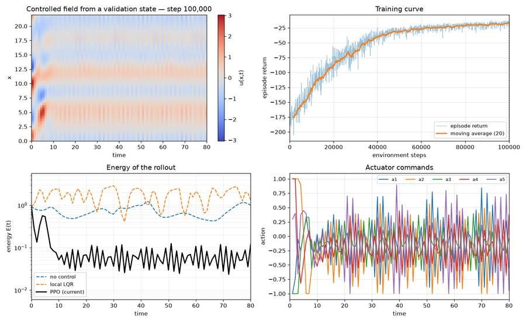

The training dashboard at the end of the 100,000 steps. Top left: the chaotic cells are removed within about ten time units and a weak standing pattern remains. Top right: the episode return climbs from about −176 to about −18. Bottom left, on a log scale: PPO holds the energy near 0.07 while the local LQR pushes it above the uncontrolled level. Bottom right: the commands saturate only at the start.

The Gymnasium KS experiment. PPO cuts the 80-step cost from 114.33 to 14.63 in the run shown here (21.77 in a repeat run on another machine, about fivefold). The local LQR more than doubles the cost of doing nothing. The 240-step test, three times the training horizon, shows that PPO holds the field down after training ends.

The local LQR is designed on the six unstable Fourier modes around u = 0, and its reduced closed loop is stable (spectral radius 0.814). It still fails, because episodes start on the chaotic attractor, far from the point where the linear model holds, and its saturated commands push the field away. PPO was trained from those states. During training the policy beat the uncontrolled run after 2,000 steps but needed 88,000 to bring a validation state below 5 % of the chaotic energy, and only 5.2 % of its final commands sit at the ±1 bound.

**Pitfall**

A learned result is one sample. The run shown here gave a PPO cost of 14.63; the same code and seed on another machine gave 21.77. The solver, the LQR and the uncontrolled runs agree to every printed digit. Quote learned numbers with their run.

**Full write-up**

This experiment is Stage 1 of the airfoil project, with all its exercises, the regulator and model-predictive references, and the numbers behind them: a flap controller trained inside a CFD-built surrogate, Stage 1.

## Eight variations: where the result stops holding

Eight variations of the Gymnasium KS experiment change one ingredient at a time. Each retrained agent is PPO with the main settings, 100,000 steps, one seed, so differences of a few percent are noise. "Success" means a final energy below 5 % of the mean uncontrolled energy, and "returned to chaos" means above 50 % of it.

[figure not shown]

Left: the number of linearly unstable Fourier modes and the estimated largest Lyapunov exponent for four domain lengths. Right: PPO retrained with 2, 3 and 5 actuators. "Rank" is the controllability rank of the six-dimensional unstable subspace; below 6 no stabilising LQR exists, so actuation authority is the limit there, whatever the learner.

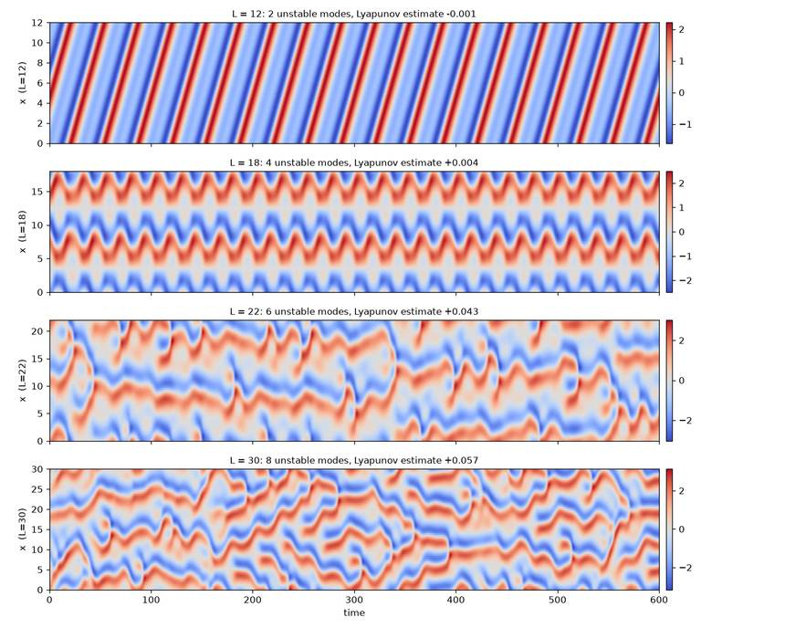

The uncontrolled field at the four domain lengths. At ℓ = 12 a single wave travels steadily. At ℓ = 18 the pattern oscillates almost regularly. At ℓ = 22 and 30 cells appear, merge and disappear without repeating.

More unstable modes means a harder problem. At ℓ = 12 there is no chaos, everything is essentially linear and LQR can do the job; at ℓ = 30 things are more chaotic and harder to control.

[figure not shown]

Partial observability made concrete. One snapshot of five values does not determine the state of the field, so the policy cannot tell which action is right. Giving it the last four snapshots restores some of the missing information: the cost falls from 98.3 to 69.4 and the returns to chaos from 95 % to 45 %.

[figure not shown]

Left: the trained policy with its commands limited more tightly. A bound of ±0.5 gives a lower cost and a higher success rate than the ±1 it was trained with: the policy over-actuates. Right: the policy trained at ℓ = 22 degrades at 23 and 24; a policy trained with ℓ drawn at random from 20 to 24 does better there and pays about one cost unit at ℓ = 22 (15.7 against 14.6). Without control the cost is 104 to 243 over this range.

[figure not shown]

Cost against online computing time. The trained policy pays its computing bill once, during training, and then answers in a fraction of a millisecond. The model predictive controller solves an optimisation with the same solver at every decision.

| Variation | What was changed | What the numbers show |
| --- | --- | --- |
| Threshold reward | No penalty once the field is below 10 % of its typical mean square | It did not reduce the control effort (5.64 against 5.18 over 240 steps) and the field spent less time under the threshold (48 % against 76 %). |
| One actuator fails | One output forced to zero after training, 240 steps | Cost 32 to 70 against 34.7 with all five. Losing actuator 1 (64.1) or 4 (70.0) hurts most. A return to chaos appeared in 2 % of the cases, for actuator 4 only. |
| Lyapunov sensitivity | Two runs started 10⁻⁴ apart | Growth rate 0.072 without control, 0.122 with LQR, 0.034 with PPO. Separation after 240 steps: 11.0, 13.6 and 0.08. |

**Key idea**

None of these limits is about the algorithm. Too few actuators, too few sensors, a reward that does not say what you want, a system that differs from the training one: these belong to the environment, which is the part you own. The Lyapunov sensitivity test adds a subtler point. Two controlled trajectories may still drift apart; the objective is a low energy, and that can hold even when individual trajectories diverge.

## Connect the dots

[figure not shown]

The lesson on one page. Top row: the three ideas behind the algorithm families. Middle: the two tools you will use most. Bottom row: what the library gives, what the experiments showed, and what no algorithm fixes.

The algorithms differ in what they learn and in which data they may use. The interface hides which physics produces the transitions. Put together, the choice of learner and the choice of model become two separate decisions, and the evidence from the experiments says the second one deserves most of the attention: what is observed, what is actuated, what is rewarded, and how much each step costs.

## Check yourself

**Why can DQN not control the five KS actuators directly?**

Its target needs the maximum of Q over all actions. With a finite list that is a comparison. With five continuous amplitudes there is no list to scan, so the maximum cannot be computed. DDPG, TD3 and SAC put an actor in its place, and PPO optimises the policy directly.

**What problem does the target network solve, and what would you see without it?**

The target r + γ max Q is computed by the network that is being trained, so each update also moves the target. A copy that is refreshed only slowly holds the target still between copies. Without it the estimate keeps chasing a goal that shifts at every step.

**In the PPO picture with ε = 0.2 and Â > 0, the ratio of some action has reached 1.35. What does this sample contribute to the next gradient step?**

Nothing. Beyond χ = 1.2 the term stays at 1.2·Â, so its slope is zero. The update has no incentive to make that action even more probable, which keeps the new policy close to the old one.

**Each environment step is one DNS time step of a turbulent channel. Which family do you try first, and what do you pay for it?**

An off-policy actor–critic such as DDPG or TD3, because every stored transition is reused in many updates instead of being discarded after one. The price is a replay buffer and a configuration of its own to tune, where PPO is known for stability and few settings.

**An environment returns `terminated = False` at every step and `truncated = True` at step 80. What does that tell the algorithm?**

That the episode stopped because the time budget ran out and the physics did not end. All environments in this guide behave this way, since none has a physical end state.

**With five point sensors the KS policy costs 98.3, with the full field 14.6. Why does stacking the last four observations help, and why only partly?**

One snapshot of five values does not determine the state of the field, so the same observation can call for different actions. Several past snapshots carry some of the missing information, such as how the pattern is moving. The cost falls to 69.4, still far from 14.6, because four frames of five points do not replace 64 points.

**In the loop with the three families, switch from PPO to TD3. Which slots change and which stay the same?**

Only the agent box changes. The Memory slot turns from a rollout of 1,024 steps that is used once into a replay buffer of 100,000 transitions sampled 256 at a time, a box with target copies of the actor and the critic appears, exploration becomes noise added to a deterministic action instead of sampling from a learned σ, and the critic takes the action as an input. The environment, its spaces, reset, step and reward are untouched: the library sizes the new networks from the same two spaces.

**Into Lesson 6**

The KS agent needed 100,352 environment steps, and the solver delivered them in about a minute. One action on a two-dimensional OpenFOAM airfoil takes about a minute of computing. The same number of steps would then be about 70 days of solver time, for a single training run with a single seed. Lesson 6 asks what to train on instead: a zero-dimensional airfoil model first, then a network that has learned lift and drag from CFD data.

Lesson 6 of 7 · 0-D airfoil model · RANS surrogate · surrogate in the loop · field model (POD / β-VAE)

# Airfoil control: reduced models and CFD surrogates

What to put inside the environment when the real simulator is too slow to train on. After this lesson you can draw the ladder of models from a three-equation airfoil to full CFD, explain how a surrogate is built, validated and plugged into the loop, and say where it can fool the agent.

**From Lesson 5**

Lesson 5 ended with library algorithms (PPO, SAC, TD3 from Stable-Baselines3) training on any Gymnasium environment, and with one uncomfortable number: training takes tens of thousands of environment steps. So far each step was a cheap ordinary or partial differential equation. This lesson asks what happens when each step is a CFD run.

## What if every step is a CFD run?

[figure not shown]

The training budget of the airfoil experiments in this lesson is 50,000 steps. Top: that many calls of the aerodynamic model alone, assuming about one minute per interaction for a two-dimensional OpenFOAM case and using the per-call times measured for the models of this lesson. Bottom: the complete training runs as measured (Apple M3 Max, CPU).

The multiplication is the whole argument: **steps needed × cost per step**. The agent cannot learn from fewer steps just because the solver is expensive. Serial CFD at a minute per step would take about five weeks for the 50,000-step budget; even an optimistic estimate for the job is one to two weeks. With a model call that takes about 0.01 ms, the aerodynamics disappear from the bill and all the remaining time is the learning itself.

**In practice**

Every time the agent moves the flap, the simulation has to be advanced to see the consequence. With OpenFOAM, even in 2D, that is about a minute per interaction, so calibrating the flap agent may take one or two weeks, and in 3D the cost is out of reach. The way out: build a second neural network that already knows the aerodynamics, and let the agent train against that.

## The fidelity ladder

[figure not shown]

The same control problem, four possible models behind the environment's `step()`. The experiments of this lesson train on steps 1, 2 and 3. Step 4 produced the database for 2 and 3 and remains the place to validate a final controller.

Each step up answers a weakness of the one below. The analytic model knows only a straight lift line. The coefficient surrogate knows camber, thickness, Reynolds number and the bend of the lift curve, because it was fitted to RANS results. The field model carries the same information through a compressed picture of the whole flow, so it can also show pressure and velocity. Full CFD is the only step with the actual moving flap and unsteady flow, and it is too slow to sit in the loop.

**Key idea**

The reinforcement-learning formulation (observation, action, reward, `reset`, `step`) and the aerodynamic model are two separate things. The ladder changes only the second. The learned policy still depends on which step produced its training experience.

## The control problem: hold the lift through a gust

[figure not shown]

The setup of the airfoil experiment with the 0-D model, a three-equation airfoil with a flap in a gust (the section shape is a schematic). A vertical gust adds to the angle of attack, the lift leaves its target, and the agent deflects the trailing-edge flap to bring it back.

This is a **disturbance-rejection** problem. Nothing has to be driven to a new place, as in the point mass of Lesson 1. The lift already sits at its target and the task is to keep it there while a gust passes. The model is a toy on purpose: it is cheap to train on and it is formulated exactly as a CFD-based environment would be.

## The 0-D model: one static law and two lags

[figure not shown]

Everything the 0-D environment computes in one step. The two lags give the system memory: the flap cannot jump to its command, and the lift does not jump to its quasi-steady value.

α<sub>eff</sub> = α<sub>0</sub> + α<sub>gust</sub> + k<sub>f</sub>·δ<sub>f</sub> C<sub>L,qs</sub> = 2π·α<sub>eff</sub> (radians)  
τ<sub>L</sub>·dC<sub>L</sub>/dt = C<sub>L,qs</sub> − C<sub>L</sub> τ<sub>f</sub>·dδ<sub>f</sub>/dt = δ<sub>f,cmd</sub> − δ<sub>f</sub>  
C<sub>D</sub> = C<sub>D0</sub> + k<sub>D</sub>·C<sub>L</sub><sup>2</sup> + k<sub>δ</sub>·δ<sub>f</sub><sup>2</sup> with C<sub>D0</sub> = 0.012, k<sub>D</sub> = 0.025, k<sub>δ</sub> = 0.08  
w<sub>g</sub>(t) = (W<sub>0</sub>/2)·[1 − cos(2π·(t − t<sub>0</sub>)/T<sub>g</sub>)] for t<sub>0</sub> ≤ t ≤ t<sub>0</sub> + T<sub>g</sub>, else 0  
α<sub>gust</sub> = atan(w<sub>g</sub>/U<sub>∞</sub>)

The first line is thin-airfoil theory with the flap folded in as an extra angle. The second line is a pair of first-order lags, the same form as a relaxation toward a steady state in a solver. Training draws a new gust for every episode: amplitude W<sub>0</sub> from −3 to 3 m/s, duration T<sub>g</sub> from 0.8 to 1.8 s, start t<sub>0</sub> from 1 to 3 s.

```
# inside step(): explicit Euler, dt = 0.05 s
self.flap_deg += (self.dt / self.tau_flap) * (flap_command_deg - self.flap_deg)
cl_qs, cd, alpha_eff_deg = self._aero(gust_angle_deg)   # the only aerodynamic call
self.cl += (self.dt / self.tau_lift) * (cl_qs - self.cl)
```

There is no mesh and no spatial coordinate, which is what "0-D" means here. Since the numerics cost nothing, if training takes time, it is the machine learning and nothing else. The environment also offers a saturating law, C<sub>L,max</sub>·tanh(2πα / C<sub>L,max</sub>) with C<sub>L,max</sub> = 1.35, because the straight line grows without limit. It still is no stall model.

## The same problem as observation, action and reward

[figure not shown]

The Markov decision process of the 0-D model experiment. The agent sees the lift, the goal, the gust angle and the flap position; it returns one flap command; the environment scores the step.

Every observation is divided by a typical size (1.5, 1.5, 10° and the 20° flap limit) so that all four inputs are of order one. The rule: scale every observation and every reward term to order one, or the largest quantity dominates and the agent optimises that one alone. An episode is 120 steps of 0.05 s, six seconds of flight, and the discount factor is γ = 0.99.

The gust angle in the observation matters. With it the agent can act the moment the gust arrives (feedforward). Without it the agent can only react after the lift has already moved (feedback). One of the variations below removes it.

## Feel it: fly the gust yourself

Below is the 0-D model environment running in this page with the same equations and constants as the training experiment (linear lift law, evaluation gust W<sub>0</sub> = 2.5 m/s, T<sub>g</sub> = 1.3 s, starting at 2 s, explicit Euler with 0.05 s). Move the flap slider to see the steady lift change. Then fly the gust by hand, or let one of two hand-written rules try.

Flap command 0.0°

gain K 2.0

[figure not shown]

Grey: the lift with the flap left at 0°, reproducing the uncontrolled RMSE of 0.1385. Press a button to add a controlled flight in blue. The two rules are illustrations written for this page; they are not the trained agent.

Two things are worth trying. First the proportional rule, a = −K·(C<sub>L</sub> − target): it only moves after an error exists, so the error never fully vanishes and raising K helps. Then the gust-cancelling rule, δ<sub>cmd</sub> = −α<sub>gust</sub> / k<sub>f</sub>: it uses the measured gust, moves at once, and is limited only by the flap lag. The −1/k<sub>f</sub> = −1.82 in that rule is the ratio the trained agent is compared against below.

**In practice**

The trained agent is not compared with a classical controller here. It is not difficult to add an LQR, and if the problem is linear a classical controller will be better. The experiment is there to show that a model can simplify the problem drastically and that a learning method captures the behaviour of the system. The learning method earns its place when the problem is nonlinear.

The simulation above agrees with that. On this linear model the gust-cancelling rule scores about the same as the trained TD3 agent, and the proportional rule gets there with a high gain. That is an observation from this page's illustration, with rules that know the model's constants; it is not a tuned classical baseline.

## Training on the 0-D model, and what the agent learned

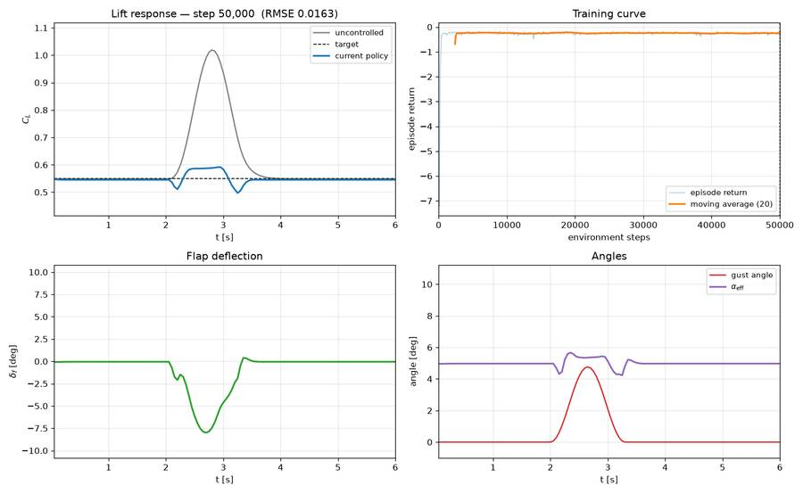

The final frame of the training dashboard of the 0-D model experiment (TD3, 50,000 steps, seed 7). Top left: the trained policy holds the lift near 0.55 while the uncontrolled lift climbs to 1.02. Top right: the episode return saturates almost at once.

How fast the learning happens on the cheap model, from snapshots of the policy recorded during training. The remaining 47,000 steps do not improve the fixed-gust error further.

[figure not shown]

The trained TD3 agent against no control, on the evaluation gust and on four gusts fixed neither in amplitude nor in duration during training (two of them stronger than any training gust).

The error drops six to thirteen times depending on the gust, with a mean flap deflection of about 1° and a peak of 8° on the evaluation gust. The flap starts to move at the gust onset (t = 2.10 s), before the uncontrolled lift error exceeds 0.01 (t = 2.20 s): the agent uses the observed gust angle to anticipate. At the gust peak the flap has moved −7.82° against a gust angle of +4.76°, a ratio of −1.64 where pure cancellation needs −1.82.

**Pitfall: one seed is one sample**

**Full write-up**

The 0-D model experiment is Stage 2 of the airfoil project: Stages 1 and 2 of the project page.

## Seven what-ifs on the cheap model

Because one training run costs seconds to minutes, every what-if question can be answered with an experiment. Each bar is a newly trained agent (TD3 unless stated, 50,000 steps, one seed).

[figure not shown]

What the agent is given and what it is asked for. All variants stay far below the uncontrolled error; the differences between them are within what a single seed can show.

Hiding the gust angle is the partial-observability test. Hiding the gust angle turns the agent into a pure feedback controller, and in this run it lost nothing: the measured lift carried enough information for these gusts. The smoothness and drag variations show the reward doing its job. Without the smoothness term the commands get rougher and the error does not improve; with a fifty times heavier drag weight the agent buys a slightly lower drag with a larger lift error.

[figure not shown]

What happens when the test differs from the training. A slower actuator or stronger gusts than those seen in training triple the error; a mildly different lift law does not.

These three are the first sight of the theme that runs through the rest of the lesson. A policy is only tested where it was trained. Change the actuator (the slower flap) or the size of the disturbance (the stronger gusts) and the error grows about three times, although the algorithm and the network are untouched. Retraining on the new condition repairs it. The saturating lift law is a change the linear-trained policy tolerates, because for these gusts the two laws stay close.

## Step 2 of the ladder: building a surrogate from RANS data

[figure not shown]

The pipeline of the RANS-surrogate experiment, which fits a small network to the public AirfRANS database. A surrogate is a model fitted to a dataset that reproduces a simulation's output at a tiny fraction of its cost.

AirfRANS holds incompressible two-dimensional RANS solutions of NACA four- and five-digit airfoils for Reynolds numbers from 2 to 6 million and angles of attack from −5° to 15°. The experiment keeps the four-digit family, whose shape is three numbers: maximum camber m, its position p and thickness t (2, 4, 12 for a NACA 2412-like section). AirfRANS samples them continuously, so the 489 cases are 489 different shapes and conditions.

[figure not shown]

The network of the RANS-surrogate experiment, with the parameter count of each layer (6,690 in total). The scaling boxes are part of the model: the saved scalers travel with the network.

The output scaling is the step people skip. C<sub>L</sub> spans about −0.5 to 1.9 and C<sub>D</sub> about 0.007 to 0.035, so a mean squared error on raw values would see only the lift. Standardising each target separately, with scalers fitted on the training set only, puts both on the same footing in the loss. Training stopped after 364 epochs and restored the weights of epoch 324, the best validation loss.

**Pitfall: drag comes first**

The force-coefficient method of the AirfRANS `Simulation` class returns drag first and lift second. Swap them and the surrogate trains without complaint on the wrong targets.

## How good is the surrogate, and where?

[figure not shown]

The two static laws at the operating point of the flap experiments (NACA 2412-like, Re = 4 × 10⁶). The surrogate sits about 0.2 above the straight line, because the section is cambered and lifts at zero angle, and it bends over toward 15°. Neither curve is new CFD.

| On the 111 test cases | C<sub>L</sub> RMSE | C<sub>L</sub> R² | C<sub>D</sub> RMSE | C<sub>D</sub> R² |
| --- | --- | --- | --- | --- |
| Surrogate, run A (the one used in the loop below) | 0.0259 | 0.9979 | 0.00087 | 0.9724 |
| Surrogate, run B (retrained, same code and seed) | 0.0209 | 0.9986 | 0.00100 | 0.9632 |
| Thin-airfoil theory 2πα | 0.3595 |  |  |  |

On unseen cases inside the database the surrogate is about 14 times more accurate in lift than thin-airfoil theory. Drag is harder: it is small and sensitive to pressure and viscous details, and in a parity plot one test case sits clearly off the diagonal. All of this is an **interpolation** score. The test cases lie inside the cloud of training cases, which is checked by plotting the parameter space before fitting anything.

Show errors of

[figure not shown]

Variations of the RANS-surrogate experiment, three seeds per configuration (green bars and points are means; grey whiskers are one standard deviation). Switch between lift and drag: the two coefficients do not always tell the same story.

**Data.** With 38 cases the lift error is 0.19, eight times the full-data value; from 189 cases on the curve flattens. The CFD budget of a surrogate is a design decision with a measurable return. **Range.** A network trained only inside a band of Reynolds number or angle makes two to five times larger errors outside it, with the same architecture and settings. **Size.** The smallest network wins on 378 cases. **Inputs.** Dropping the Reynolds number costs little in lift and clearly more in drag, which is partly viscous.

**Ensemble.** Five networks trained from different seeds, averaged, halve the lift error (0.0129 against 0.0245 for one member). Their disagreement, the spread, doubles outside the training angles, so it works as a cheap warning light for extrapolation. It is a rough one: the spread correlates with the actual drag error (rank correlation 0.53) and hardly with the lift error (0.11).

**What the surrogate cannot do**

It is static: it returns steady RANS coefficients and knows nothing of unsteady lift, vortex shedding, dynamic stall or gust history. It has no flap input, because AirfRANS contains no deflected flaps. And outside the ranges of its database it returns smooth, plausible numbers with no warning attached.

## Plugging the model into the loop: swap one box

The surrogate-in-the-loop airfoil experiment takes the environment of the 0-D model and replaces the function `_aero`. The result is a loop with two neural networks in it, and they play opposite roles. Click any component to see what it holds, what goes in and out, and the code it corresponds to.

[figure not shown]

Click a component (or focus it and press Enter) to see what it holds in the surrogate-in-the-loop experiment, its inputs and outputs, and the code behind it.

The anatomy of the surrogate-in-the-loop experiment (SAC main run). Solid arrows carry data; dashed arrows carry weight updates, and they stay inside the agent. The thick box is new: a second neural network, fitted beforehand and never trained here, sits inside the plant and answers one question per step. The 0-D model run has the same picture with a formula in place of the thick box and TD3 in place of SAC.

Two networks, two roles. The policy network is the thing being trained: its weights change after every step of the 50,000. The surrogate network is part of the physics: it was fitted once to RANS data, it is called 50,000 times, and its weights never move. Nothing in the agent knows or cares that the plant contains a network. Press the buttons below to exchange the aerodynamic model and watch what else moves.

Model inside the environment

[figure not shown]

The loop shared by the 0-D model, the RANS surrogate and the field model. Only the thick box changes. The flap still acts through an equivalent angle, and both lags stay, because the RANS data are steady and contain no flap. The three rows at the bottom open the box: every model takes the equivalent angle in and hands two coefficients back, but between those two ends sit two formulas, one network of 6,690 weights, or two networks joined by an 8-number latent state. The selected model is drawn in full, the other two faded.

**Static law**An MLP with 6,690 parameters fitted to 378 RANS cases, evaluated at (Re, α<sub>eq</sub>, m, p, t).

**Target C<sub>L</sub> at zero gust**0.7595, the surrogate's own lift at α₀ = 5°.

**Lift slope near 5°**6.51 per radian (thin airfoil: 2π = 6.28).

**Cost of one call**0.011 ms as a NumPy forward pass; 16.7 ms through Keras `predict`.

| From 0-D model to surrogate in the loop | Stayed the same | Changed |
| --- | --- | --- |
| Agent side | Observation (4 scaled numbers), action, reward terms and weights, γ = 0.99, 120-step episodes, 50,000 training steps | The main run uses SAC (the 0-D model run used TD3) |
| Dynamics | Flap lag 0.10 s, lift lag 0.18 s, gust shape and ranges, flap effectiveness 0.55 | Nothing |
| Aerodynamics | The flap still enters only as an equivalent angle | C<sub>L,qs</sub> and C<sub>D</sub> come from the surrogate; Re and (m, p, t) become environment parameters; the target becomes the surrogate's zero-gust lift, 0.7595 (the 0-D model used 0.55) |

**Key idea**

Replacing 2πα by the surrogate changes the map from (state, action) to (next state, reward). So the best policy can change although observation, action, reward weights and algorithm are identical. Put plainly: a DRL controller can only be as trustworthy as the environment used to train and validate it.

It helps to be exact about what this is: steady CFD-informed coefficients embedded in low-order unsteady dynamics, and no CFD simulation of a moving flap. A flap-dependent, ideally unsteady, dataset would remove the equivalent-angle shortcut. Such data are hard to find.

## Two networks, two kinds of learning

Open both boxes. On the left, the networks of the agent: the actor that turns four observation numbers into one flap command, and the critics that score a state and an action. On the right, the surrogate inside the plant. Same building blocks, opposite roles.

[figure not shown]

Inside the networks. Input neurons carry environment data (green), the rest belongs to whoever owns the network. The actor and critics are the Stable-Baselines3 `MlpPolicy` of the SAC run; their layer sizes are not set in the experiment, so the library defaults apply and are drawn without numbers. SAC's actor outputs a mean and a log-spread, samples, and squashes with tanh; the dashed path is the evaluation flight. (TD3 outputs the action directly and adds noise outside the network; PPO keeps one log σ that does not depend on the state.) The surrogate has every size fixed by its design: 5-64-64-32-2 with tanh, 6,690 weights, and the two scalers travel with it.

The two networks were also trained in different ways, and the picture below puts the two procedures side by side. The surrogate learned by **supervised regression**: every input row has a known answer from RANS, the loss is a distance to that answer, and a few hundred passes over 378 rows are enough. The policy learned by **reinforcement**: nobody knows the right flap command, the loss is built from rewards and the critic's own estimate, and the data are generated while learning. Press Step to walk through the stages in parallel.

[figure not shown]

Six stages on each side. Press Step to follow both pipelines one stage at a time.

The two training procedures with the shapes of what moves between stages. They share the skeleton (data, forward pass, loss, backward pass, optimizer step, repeat) and differ in every box. The thick green arrow is the only connection: the finished surrogate is loaded into the environment before the reinforcement loop starts. Dashed arrows never cross into the environment, on either side.

**Key idea**

Gradients flow from a loss into the weights of the network that owns the loss, and nowhere else. The surrogate's gradients stopped when its fit ended. During reinforcement learning the surrogate, the lags and the gust are only called, never differentiated: the agent learns from the rewards they return, exactly as it would from a CFD solver.

## What the surrogate environment taught the agent

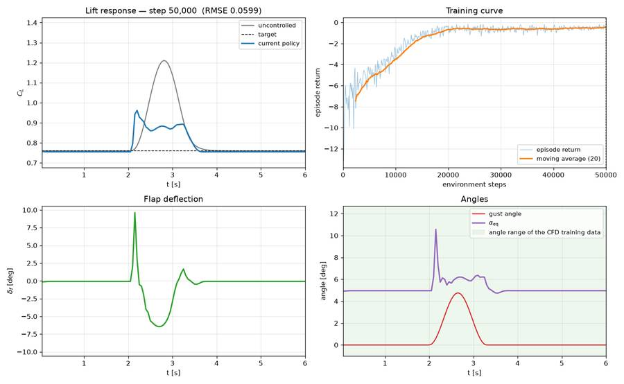

The final frame of the training dashboard with the surrogate in the loop (SAC, 50,000 steps). The shaded band in the last panel is the angle range of the CFD training data. Look at the flap at t ≈ 2.1 s: its first move is in the wrong direction.

[figure not shown]

Two variations with the surrogate in the loop: the algorithm and the reward weights. With the same budget PPO and TD3 do far better than the SAC main run. Raising the effort weight from 0.015 to 0.2 gives a controller that barely acts.

### Train on one model, test on another

[figure not shown]

The model cross-test. The diagonal is "trained and tested on the same model"; the off-diagonal is a model mismatch. The surrogate-trained agent, moved to the thin-airfoil model, is no better than leaving the flap alone.

The two static laws differ by about 0.2 in lift at every angle up to 10°, and the two environments aim at different targets (0.7595 and 0.5483). An agent that never observes which model it is in cannot correct for that. A caution is in order: these are single SAC seeds, and SAC was the weakest algorithm at this budget, so the size of the asymmetry is uncertain. The direction of the lesson is not.

### Change Reynolds number or the section shape

[figure not shown]

Changing the Reynolds number, at test time and in training. The policy trained at Re = 4 × 10⁶ works equally well from 2 to 6 million, because the surrogate's response to Re is mild there. Randomising Re at every `reset` gave a worse policy in this run.

Randomising a parameter during training (domain randomisation) is the standard way to make one policy cover a family of conditions. Here it did not pay: the error rose from 0.053 to 0.089. A repeat run with a retrained surrogate showed the opposite ordering. With one seed per case, neither direction is a finding. What the experiment does establish is the procedure: draw Re in `reset()`, set the target to that Re's own zero-gust lift, and evaluate over the whole range.

[figure not shown]

Changing the section shape. The policy trained on the 2412-like section, tested on eight sections inside the database. Red bars are worse than not controlling at all. The second label row is each section's zero-gust target lift; training was at 0.76.

Shape matters far more than Reynolds number. The policy carries over to sections whose lift at 5° is near the one it trained on (2418, 4412, 4415). On the symmetric 0012 and 0018 and on the strongly cambered 6409 and 6412 it does harm. Being able to *test* on any geometry, because geometry is a surrogate input, is different from being robust to it: nothing in the observation tells the agent which section it is flying.

**Full write-up**

The surrogate and the controller trained inside it, with every exercise, the domain-penalty test and the comparison of two executions, are Stages 3 and 4 of a flap controller trained inside a CFD-built surrogate.

## The danger zone: where the agent takes the surrogate

Gust amplitude W₀ 3.0 m/s

[figure not shown]

Bars: the equivalent angles each policy sent into the surrogate in the surrogate-in-the-loop runs, with the share of time steps outside the data. Bottom row: what the ±20° flap could reach at the peak of the gust you choose, from α<sub>eq</sub> = 5° + α<sub>gust</sub> + 0.55·δ<sub>f</sub>. The dot is the flap at 0°.

The green band is the only region where anybody has checked the surrogate against CFD. The agent decides where the surrogate is evaluated, through α<sub>eq</sub>. A well-trained policy keeps α<sub>eq</sub> close to 5°, since holding the lift means cancelling the gust (PPO stays between 4.6° and 5.5°). But the flap alone can move α<sub>eq</sub> by ±11°, and an exploring agent uses that freedom. With wide gusts the unprotected SAC agent reached 19.9°, five degrees beyond any training case.

[figure not shown]

Three models fitted to the same 378 RANS cases: the direct MLP and the two field-model chains (POD and β-VAE, introduced below). Inside the data they differ by at most 0.05 in C<sub>L</sub>. Outside, the gap opens to 0.19 at −10° and 0.17 at 20°, and none of them shows a stall.

Outside the band each model continues its curve in its own way, and no CFD says which is right. Real airfoils stall there. An agent that maximises reward does not care whether a favourable lift value is physics or fitting error, which is how a policy ends up exploiting the model instead of the flow.

**Pitfall: the agent exploits model error**

A DRL agent searches for whatever maximises its reward, including the errors of the model it trains on. In a surrogate environment, watch where the agent drives the surrogate's inputs and penalise excursions outside the data range.

r<sub>domain</sub> = −λ<sub>domain</sub>·[ max(0, α<sub>eq</sub> − α<sub>max</sub>)<sup>2</sup> + max(0, α<sub>min</sub> − α<sub>eq</sub>)<sup>2</sup> ]  
with λ<sub>domain</sub> = 0.1 per deg², α<sub>min</sub> = −4.91°, α<sub>max</sub> = 14.84°

That is the protection a domain penalty adds to the reward, with the limits read from the training table instead of chosen by hand. With gusts up to ±6 m/s in training it cut the time outside the data from 4.6 % to 0.8 % and also lowered the error (0.213 against 0.261). Keep the scale in mind: on these very strong test gusts neither agent does much better than a fixed flap (0.264). The other protections: monitor α<sub>eq</sub> in every evaluation, use the spread of an ensemble as a warning, randomise the parameters the policy should be robust to, and finally test the controller on a model that was not used in training.

## Step 3 of the ladder: a field model in the same environment

The field-model (POD / β-VAE) experiment builds a second route from the same 489 cases to the same two coefficients. It first compresses each whole flow field into 8 numbers, a reduced-order model (ROM), and then predicts those 8 numbers from the parameters.

[figure not shown]

Picture 1: the reduction. POD, familiar from CFD post-processing, writes a field as a weighted sum of fixed modes. The β-variational autoencoder (β-VAE) learns a curved compression instead; its extra KL term keeps the 8 coordinates smooth and well spread. Errors are mean squared errors on standardised test fields.

[figure not shown]

Picture 2: the chain that replaces `_aero`. Parameters go to latent coordinates, a small head reads the coefficients from them, and the decoder can turn the same coordinates into a flow field.

On the 111 test cases the β-VAE chain predicts the coefficients about as well as the direct network (C<sub>L</sub> RMSE 0.0212 against 0.0259, C<sub>D</sub> 0.00074 against 0.00087). Most of its field error comes from the compression to 8 numbers, hardly any from predicting those numbers. For the environment, the consequences are four.

[figure not shown]

Cross-test between the two data-driven environments: PPO, three seeds per training environment, mean ± standard deviation over seeds. Where a policy was trained makes no measurable difference here.

**Policies transfer both ways.** Compare this table with the earlier cross-test between the surrogate and the thin-airfoil model. There the two models disagreed by about 0.2 in lift and the transfer failed. Here they disagree by at most 0.05 inside the data, their targets are 0.7595 and 0.7483, and a policy trained in either environment scores the same in both. Transfer between models is as good as the agreement between the models along the path the policy flies. **The cost is the same.** One call takes 0.014 ms against 0.011 ms, and a PPO run takes 11 s in either environment.

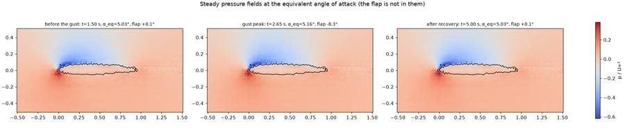

Pressure fields decoded along one controlled flight in the field-model environment. They are steady fields at the equivalent angle of that instant, and the flap is not in them.

**It can show the flow.** The three panels look almost alike, and that is the result: at the gust peak the gust adds 4.76° and the flap takes 8.25° × 0.55 away, so α<sub>eq</sub> moves only from 5.03° to 5.16°. The controller holds the flow state nearly constant. **It shares the same limits.** Both models saw the same 378 cases, so their trusted box is identical. The picture has no flap and no unsteadiness, because the data have none.

**Full write-up**

The field model, its design search and the cross-test in this environment are Part 2 of the airfoil series: reduced-order models, a β-VAE and a latent-space design search.

## Is this transfer learning?

[figure not shown]

Two ideas that are easy to confuse: reusing one trained network on a new case, and generating new cases from one latent space.

Can the simple model be used for initial training before switching to CFD? Yes: that is the purpose of the surrogate. The complete version goes through a latent space: compress many simulations with a reduced-order model, advance the latent state in time (for example with a Koopman operator), and control the latent state instead of the CFD. With about ten numbers and a decoder, that is fast.

Is that essentially transfer learning? Not quite. Transfer learning takes a model trained for one case and uses the same network for another. A latent space is trained once on simulations that vary everything of interest, and new situations come from changing the latent values. One network trained on many configurations and steered to new ones is the idea behind a foundation model. The field-model chain of this lesson is a small, static version of that idea; the time evolution in latent space is the part this lesson does not build.

**In practice**

Optimising lift or drag with a surrogate is easy, because it is optimising one function. Then validate with CFD, which takes only one CFD simulation.

## The working rule: train cheap, test on something better, know your range

[figure not shown]

The sim-to-real pattern of this lesson, with "real" replaced by "the next step up the ladder". Stages 1 to 3 are carried out in this lesson. Stage 4, a CFD run of the final controller, is the one left open.

The cheap model is where the thousands of trials happen. The better model is the examiner, and it must be one the agent did not train on. The range check says whether the examiner's own answers can be trusted along the path the policy takes. The same pattern appears at research scale: agents trained only on a cheap channel-flow environment that were then applied to a wing section without retraining.

## Connect the dots

[figure not shown]

The vocabulary of the lesson around its one move: keep the loop, exchange the model behind `step()`.

Read the map from the top row to the bottom row. The top row is what you build: a ladder of models, an environment that does not care which one it holds, and a recipe for turning CFD data into a fast function. The bottom row is what you owe the result: knowing how it fails, guarding against that, and seeing where the idea is heading.

## Check yourself

**Why can't the flap agent simply be trained on OpenFOAM?**

Training needs tens of thousands of environment steps, 50,000 in the experiments of this lesson, and each step must advance the flow. At about one minute per interaction that is on the order of 35 days of solver time for one training run, against under a second of model calls with the surrogate.

**In going from the 0-D model to the surrogate in the loop, which lines of the environment change, and why can the learned policy still be different?**

Only the aerodynamic function `_aero` (and with it the zero-gust target, 0.7595 in place of 0.55). Observation, action, reward weights, lags, gust and algorithm settings stay. The policy can differ because the map from state and action to next state and reward is different, and the policy is optimal only for the transitions it trained on.

**The surrogate has no flap input. How does the flap act with the surrogate in the loop, and what does that cost in realism?**

Through an equivalent angle, α<sub>eq</sub> = α₀ + α<sub>gust</sub> + 0.55·δ<sub>f</sub>, at which the steady surrogate is evaluated; the flap lag and the lift lag supply the dynamics. So the environment is steady RANS coefficients inside low-order dynamics. It contains no flow around a deflected flap and no unsteady aerodynamics.

**The surrogate scores R² = 0.998 for lift on the test set. Why is that no licence to use it at α = 18°?**

The test cases lie inside the training cloud, so the score measures interpolation. The data end at 14.84°. At 18° the three models fitted to the same cases give 1.83, 1.73 and 1.69, none shows stall, and nothing in the output warns about it. The training-band variation measured the same effect: errors two to five times larger outside a training band.

**The surrogate / thin-airfoil cross-test and the surrogate / field-model cross-test both move a policy to a model it was not trained on. Why does one fail and the other succeed?**

In the first the models are thin-airfoil theory and the RANS surrogate, about 0.2 apart in lift with different targets, and the surrogate-trained agent ends at 0.144, near the uncontrolled 0.151. In the second the two models were fitted to the same data and agree within 0.05, and scores stay between 0.0095 and 0.0106. Transfer works to the extent that the models agree where the policy flies.

**Two neural networks sit in the surrogate-in-the-loop environment. Which one learns during training, how did the other one get its weights, and why does no gradient ever reach it?**

The policy networks (actor and critics) learn: their weights change after each batch of 256 transitions, driven by the reward. The surrogate got its 6,690 weights earlier by supervised regression on 378 RANS cases (MSE, Adam, early stopping) and is then frozen. During reinforcement learning it is only called inside `step()`, 5 numbers in and 2 out; the loss is built from rewards and critic values, and its gradient is taken with respect to the actor and critic weights alone. The environment, surrogate included, is never differentiated, exactly as a CFD solver would not be.

**Name three ways to keep the agent from exploiting surrogate error, and what each one did or would do in the runs of this lesson.**

**Into Lesson 7**

This lesson controlled two numbers of one airfoil with one flap, and it could afford a cheap model because lift and drag compress well. Turbulence does not offer that shortcut. In Lesson 7 the environment is a direct numerical simulation of a turbulent channel, the quantity to reduce is the wall friction, and the actuators are blowing and suction at every wall grid point: 256 agents in the minimal channel and 4,096 in the larger one. How do you train thousands of agents when every step is expensive again?

Lesson 7 of 7 · Published case studies in flow control

# DRL for turbulence and flow control

The loop from Lesson 1 is now wrapped around a direct numerical simulation of turbulence. After this lesson you can explain how it scales to a whole wall through many identical agents, how a study is judged, and how the reward decides which physics the agent attacks.

**From Lesson 6**

Lesson 6 controlled one flap on one airfoil, and it trained on cheap models because CFD inside the loop was too expensive. The research in this lesson takes the opposite step: the environment *is* the expensive simulation, a direct numerical simulation (DNS) of a turbulent channel, and the thing being controlled is the turbulence itself. The question for this lesson: how can trial and error work when the wall has hundreds of actuators and every step costs a DNS time step?

## The same loop, now with a DNS inside

Nothing in the loop of Lesson 1 has changed. Only the contents of the two boxes and the meaning of the three arrows are new (the set-up of Guastoni et al., 2023).

|  | Lesson 1: mass on a line | This lesson: turbulent channel |
| --- | --- | --- |
| Environment | two lines of Python | DNS of an open channel at friction Reynolds number Re<sub>τ</sub> = 180 |
| State | position error and velocity | streamwise and wall-normal velocity fluctuations u′, v′ at y⁺ = 15 |
| Action | one force in [−1, 1] | a wall-normal velocity at every wall grid point, in [−u<sub>τ</sub>, u<sub>τ</sub>] |
| Reward | minus (miss distance + effort) | relative reduction of the wall shear stress |

r<sub>t</sub> = 1 − τ<sub>w</sub> / τ<sub>w,unc</sub> = R<sub>D</sub> (averaged over the whole wall and over the time between two actions)

τ<sub>w</sub> is the wall shear stress and "unc" means the uncontrolled flow, so the reward is the drag reduction R<sub>D</sub> itself. Every study in this lesson is model-free: the agent never sees the Navier–Stokes equations, only samples of interaction. The Markov decision process behind this is Lesson 2; the algorithms named below (DDPG, TD3, PPO) are Lesson 5.

## The environment: a turbulent open channel

[figure not shown]

Side view, drawn to scale: the channel is 180 wall units high and the sensing plane sits 15 wall units above the wall, where the near-wall fluctuations are strongest. Each wall cell reads u′ and v′ directly above itself and sets its own wall-normal velocity.

An open channel has a no-slip wall at the bottom and a symmetry condition at the top. That simplifies the outer layer and isolates the near-wall turbulence that produces the friction. The wall is the only place the agent can touch the flow, and one plane is the only place it can look.

[figure not shown]

Top view of the wall, both domains at the same scale (streamwise × wall-normal × spanwise in channel heights h). The streaks are sketched, not simulated. The minimal channel is the cheap training ground; the larger one is the test of whether the policy holds up.

A minimal channel is the smallest periodic box that still sustains near-wall turbulence. It is cheap and it holds a single low-speed streak, so the dynamics are simpler than in a real wall flow. The larger channel has several streaks that interact, which is physics the small box cannot show.

## The yardstick: opposition control

Opposition control, a reactive scheme about 30 years old: sense the wall-normal velocity on a plane, impose the opposite velocity at the wall directly below.

v<sub>wall</sub>(x, z, t) = −α · [ v(x, y<sub>s</sub>, z, t) − ⟨v(x, y<sub>s</sub>, z, t)⟩ ]

y<sub>s</sub> is the height of the sensing plane, α a positive gain (usually 1), and ⟨·⟩ the mean over the plane. Subtracting the mean keeps the net mass flux through the wall at zero. It is a linear, proportional law. With sensing at y⁺ = 15 the implementation in the paper gave 25.67 % drag reduction, against about 25 % in the literature, which confirms the baseline was reproduced properly.

**Key idea**

This is Lesson 3's rule again: a learned controller means nothing without a classical reference next to it. On the point mass the references were PD and LQR. Here it is opposition control, and the environment was deliberately built from the same sensors and actuators so that the comparison is fair.

## One agent for the whole wall does not scale. Many identical agents do.

Try the two set-ups on the wall of the minimal channel. Hover or click a tile to see what that cell observes and does.

[figure not shown]

Single agent: one network must read all 512 numbers (u′ and v′ over 256 cells) and choose all 256 wall velocities together. Multi-agent: each tile runs the same small network on its own two numbers. Because that network is local, it runs unchanged on the 64 × 64 wall of the larger channel.

With one agent, the action has as many components as there are actuators. Trial and error has to search a 256-dimensional action space, and the search grows beyond what exploration can cover: the curse of dimensionality. The way out comes from the flow itself. The channel is homogeneous and periodic along the wall, so its statistics are the same everywhere.

So the wall is cut into small regions called **pseudo-environments**. They are instantaneously different and statistically identical: different trajectories of the same problem. Each one is an agent with its own local state and its own action, and all of them share one network. That is **multi-agent reinforcement learning (MARL)** with a translationally invariant policy.

Click any box, or focus it and press Enter, to read what it holds here.

[figure not shown]

Click a component to see what it holds in the channel study, its input and output, and the code it corresponds to.

The loop of Lesson 1 with its components, for the channel study. Every wall cell runs a copy of the agent with the same weights θ; the copies read two numbers each and return one each, the reward is one number paid to all of them, and their transitions are pooled into one replay buffer. Switch to "Single agent" to see the same drawing without the sharing: one network reads 512 numbers and returns 256.

**Training in parallel**Every tile contributes a transition at every solver step, from one simulation. With a wall cut into only 4 × 4 regions that already means 16 times the experience.

**Small search space**The network's action stays one number, however many actuators the wall has.

**Portable policy**A local policy can be applied to a larger wall with more tiles, provided the physics it exploits is present there.

How much of each agent's reward comes from its own region (λ<sub>loc</sub>) in the multi-agent studies of this lesson. In the channel the reward is entirely common: the drag of the whole wall.

r<sup>(j)</sup> = λ<sub>loc</sub> · r<sup>(j)</sup><sub>loc</sub> + (1 − λ<sub>loc</sub>) · r<sub>glob</sub>

The reward of agent j mixes a local part, computed in its own pseudo-environment, with a global part computed over the whole domain. A common reward is what makes the agents cooperate: each tile is paid for the drag of the whole wall, so no tile gains by improving its own patch at its neighbours' expense.

**Rule of thumb**

One agent could handle the regions one after another, but that is much less effective. With separate models and rewards each region optimises locally. With shared parameters and a collective reward the regions work together. Multi-agent training is the key to making reinforcement learning work in turbulence and other high-dimensional systems.

## How the Fortran solver and the Python learner talk

Seven messages make one turn of the loop. Press Step to walk through them.

[figure not shown]

The coupling of the channel study. The Python learner starts the solver as a second group of MPI processes; all traffic between the two goes through solver process 0, which already gathers data for writing statistics to disk.

The practical obstacle is two languages. The pseudo-spectral solver SIMSON is Fortran, parallelised with the Message Passing Interface (MPI). The reinforcement-learning libraries (for example Stable-Baselines3 and Tianshou, built for the Gymnasium interface of Lesson 5) are Python. The trick is MPI dynamic process management: Python spawns the solver, and an MPI intercommunicator carries states, reward and actions between the two groups.

The gain is that the validated parallel solver needs only minimal changes. The price is that dynamic process spawning does not work directly on every supercomputer. In Lesson 5 terms, process 0 is where `step()` lives: it takes the actions, lets the solver advance, and returns observations and reward.

[figure not shown]

What the solver receives (the signal itself is an illustration). A new action arrives every Δt⁺ ≈ 0.6, the wall velocity ramps linearly from the old value to the new one, and it can never leave the band ±u_τ.

| Setting | Value in the channel study |
| --- | --- |
| Algorithm | DDPG, a model-free, off-policy actor–critic (mechanics in Lesson 5) |
| Action interval and bounds | Δt⁺ ≈ 0.6, linear transition, v<sub>wall</sub> ∈ [−u<sub>τ</sub>, u<sub>τ</sub>] |
| Exploration | Gaussian noise of variance 0.1 u<sub>τ</sub> added to the deterministic action |
| Replay buffer | 5,000,000 transitions |
| Gradient work per policy update | 64 mini-batch updates |
| Policy update interval | every Δt⁺ = 180 |
| Episode length | 3,000 interactions |

Worked example with the episode length from the table. One simulation produces 256 times the experience a single agent would get, and the buffer keeps the most recent six or so episodes for reuse.

### Inside the agent: the actor, the critic and one update

The two networks of the channel agent. Green neurons carry environment data, the blue input of the critic is the action itself: the critic scores a (state, action) pair, so it can tell the actor which way to move its output. The number of hidden units is not given in the published description, so the layers are drawn without sizes.

One turn of the loop and one DDPG update, with the array shapes. Press Step to follow the data.

[figure not shown]

One turn of the loop (top row, left to right) and one DDPG update (bottom row, right to left). Data arrows are solid, gradients and weight copies dashed. The loss is computed from stored transitions, so its gradient reaches the critic weights ω and, through ∂Q/∂a, the actor weights θ; it never passes through the solver. The minibatch size and γ are not given in the published description.

## What the agent achieved, and how it differs from the baseline

[figure not shown]

Two honest details from the paper. Learning was sensitive to the initial condition of the episodes, and not every training run produced a drag-reducing policy. The policies that did learn then performed consistently in testing from six different initial conditions. Neither controller relaminarised the flow, which at this Reynolds number would give the upper bound of 73.9 %.

The character of the two actuation signals at one wall point (a schematic, not data). Opposition control is proportional to the fluctuations, so it shrinks as the flow calms down. The DRL policy jumps between its bounds.

The learned strategy is a two-step, bang-bang control: it switches between +u<sub>τ</sub> and −u<sub>τ</sub> and disrupts the near-wall cycle. Opposition control is linear by construction. The agent found a nonlinear strategy that no proportional law can express, and in the minimal channel it attenuates the streak through a streamwise travelling wave.

### Quadrant analysis: what "no predominance of Q2 and Q4" means

[figure not shown]

Joint distribution of u′ and v′ at y⁺ = 15 (shapes drawn schematically). Without control the cloud lies along Q2 and Q4. Opposition control shrinks it and keeps its shape. DRL makes it nearly symmetric in v′.

Split every instant at the sensing plane by the signs of u′ and v′. **Q2, an ejection**: slow fluid (u′ < 0) moving away from the wall (v′ > 0). **Q4, a sweep**: fast fluid (u′ > 0) moving toward the wall (v′ < 0). In both, u′v′ is negative, and those are the events that carry the Reynolds shear stress and feed the wall friction. Ordinary wall turbulence is dominated by them.

Opposition control reduces the range of the fluctuations, yet ejections and sweeps still dominate. Under DRL the streamwise fluctuations drop, the wall-normal ones grow, and the four quadrants become evenly populated. "Lack of predominance of Q2 and Q4" therefore says the agent broke the mechanism that produces friction, where the baseline only turned its volume down. In the larger channel the same change appears, less evenly.

## Does the saving survive the cost of actuation?

Blowing and suction need power. A controller that saves drag by spending more than it saves is useless, so the bookkeeping has two lines.

W<sub>in</sub> = ½ |v<sub>wall</sub>|³ S<sub>net</sub> = [ c<sub>f,unc</sub> − (c<sub>f</sub> + W<sub>in</sub>) ] / c<sub>f,unc</sub> = R<sub>D</sub> − W<sub>in</sub> / c<sub>f,unc</sub>

[figure not shown]

Why the first channel study could call the cost negligible: the wall velocity is of order 10⁻², so its cube is of order 10⁻⁶, three decades below the skin-friction coefficient. The cost is then about a tenth of a percentage point.

S<sub>net</sub> is the net energy saving, c<sub>f</sub> the skin-friction coefficient, and W<sub>in</sub> the actuation power per unit wall area (after Kametani et al.). The second form reads: net saving = drag reduction minus actuation power as a fraction of the uncontrolled friction. The later study counted the power more strictly, adding the pressure work at the wall and allowing no energy recovery. Then the cost is of order 10⁻⁴ and it separates the controllers.

[figure not shown]

The bookkeeping to scale, all in percent of the uncontrolled friction (larger channel). Gross drag reduction minus actuation power leaves the net saving. The two DRL rows come from the study in the next section.

**Pitfall**

Report both numbers. The actuation cost is recovered as R<sub>D</sub> − S<sub>net</sub>, and it can reorder controllers: the bang-bang policy trained on the drag reward pays 6.0 points for its 31.9, twice what the SHAP policy pays. Also watch the units. "5.6 % better" (a ratio of two drag reductions) and "1.8 points better" (their difference) describe the same pair of results.

## The reward decides which physics the agent attacks

[figure not shown]

The explainable-DRL study (Beneitez et al., 2025): the same multi-agent channel trained four times, each time paid for reducing a different quantity. Only the reward changes.

Lesson 1 said the reward is the only channel through which the goal reaches the agent. This study tests that statement on turbulence. The wall shear stress is the symptom; the structures that keep the near-wall cycle alive are the disease. Earlier work used SHAP (Shapley additive explanations) to rank how much each flow region matters for predicting the future flow, and found that the important regions overlap only partly with the classical structures.

So three rewards replace the drag by a volume integral: Q events (with U the long-time mean profile), streaks, and the magnitude of the SHAP field. Computing SHAP values inside a training loop would be far too slow, so a U-Net trained on uncontrolled flow predicts the SHAP field from the velocity, over 200 times faster. The policies were trained in the minimal channel and evaluated in the larger one over 150 initial conditions.

[figure not shown]

The reward slot of the anatomy loop, opened for the SHAP reward. A U-Net trained beforehand on the uncontrolled flow predicts the SHAP importance field from the velocity (the pattern drawn is an illustration); the magnitude of that field is integrated over the volume, and the reduction of the integral is the one number the agent receives. The network sits inside the environment's reward, is never updated during training, and no gradient flows through it.

Results in the larger channel (Beneitez et al., 2025). The amber bar between the two dots is what each controller spends on actuation. Switch the ranking: the drag-reward policy is second by drag reduction and third by net saving.

The SHAP policy gives 33.7 % drag reduction and 30.6 % net saving, the best in both. The Q-event policy is the best at reducing Q events and streaks, yet worse at reducing drag, which says the classical structures are not the most important ones to target. The SHAP actuation is also more targeted: it rarely reaches the bounds and needs about half the power of the drag-reward policy.

**Intuition**

The shear stress is the symptom and the underlying structures are the disease. Going after the disease gave better performance, with fewer large oscillations and a much lower control power.

Why would a proxy beat the real objective? The authors' reading is partial observability. The agent sees one plane, so the problem is not fully Markovian (Lesson 2), and the SHAP field acts as a sophisticated form of reward shaping: a signal that points at the cause before the drag responds. Ordinary reward shaping is limited by the expert who designs the proxy. Here the proxy is identified from data by an explainable model.

## Separation bubbles: learning the forcing a human would tune by hand

[figure not shown]

The two-dimensional case (Guastoni et al., 2022): suction and blowing on the top wall impose an adverse pressure gradient, and the flow separates from the bottom wall. The agent acts upstream of the bubble.

Here the agent does not pick a velocity at every wall point. It learns one number per step: the amplitude a<sub>y</sub>(t) of a prescribed Gaussian-shaped body force that emulates blowing and suction. The state is 24 streamwise-velocity probes upstream of and inside the bubble, and the reward is the time-averaged bubble length. The baseline is the classical one for separation: periodic (harmonic) forcing at a fixed frequency.

[figure not shown]

The three-dimensional turbulent bubble on a flat plate, seen from above (a schematic). Wall-resolved large-eddy simulation; six spanwise actuators form three pairs, and each pair is one agent of a shared PPO policy. Grid sizes are degrees of freedom.

[figure not shown]

DRL (PPO) against periodic forcing. The two-dimensional numbers come from a conference abstract and are approximate. In three dimensions the agent trained on the coarse grid was moved to the fine grid without retraining: it still beats the baseline, by a smaller margin.

What the agent learned (heights are schematic). The periodic baseline forces at one frequency. The learned control keeps that frequency, adds higher harmonics of it, is smoother, and conserves mass at every instant instead of over a period.

The rule to draw from this case: train on the cheapest simulation that still captures the main flow features, and deploy on the expensive one. That is Lesson 6's idea carried to a turbulent flow, with a coarse grid playing the role the surrogate played for the airfoil.

## Rayleigh–Bénard convection: single agent against multi-agent, same problem

[figure not shown]

The two-dimensional problem (Vignon et al., 2023), domain 2π wide and 2 high, drawn to scale; the cells are sketched. The agents set the temperatures of 10 bottom-wall segments to lower the Nusselt number Nu, the dimensionless convective heat transfer.

A fluid between a hot bottom wall and a cold top wall forms convection cells that carry heat upward. The goal is less heat transfer. This case matters for the guide because it runs the two set-ups of the wall-grid figure above on the same problem with the same training budget.

[figure not shown]

Left: one agent sets all 10 temperatures together. Right: each segment is a pseudo-environment that sees the probe grid re-centred on itself; all share one PPO network (γ = 0.99) and a reward that is the global Nusselt number with about 10 % local weight.

After 350 episodes the multi-agent policy had cut Nu by 22.7 %, the single agent by about 5.1 %. Two reasons follow from the picture. The multi-agent network solves a one-output problem instead of a ten-output one, and it receives ten times the experience from each simulation: 2,000 actions against 200.

What the agents found, on their own: concentrating heat near the centre breaks the second convection cell and establishes one larger cell with a lower heat-transfer rate. That state is stable and persists when the control is switched off. The cooperation comes from the common reward; there is no message passing between neighbours.

[figure not shown]

The three-dimensional extension uses 64 square bottom segments, each observing 128 probes, against the best proportional controller. Irregular convection patterns become regular straight rolls, so the two-dimensional conclusions carry over.

## Cylinder wakes: the strategy changes when the physics changes

[figure not shown]

Left: the two-dimensional set-up (probe positions sketched). Right: a top view of the cylinder, split along its span into ten jet pairs that share one PPO policy; 80 % of each agent's reward is local.

The same algorithm, the same sensors and jets, two different strategies (waveforms are schematic). Nobody told the agent that the physics changes with Reynolds number; the reward did.

In two dimensions (Varela et al., 2022) the agent rediscovers an opposition-type strategy up to Re = 1000 and switches to a different mechanism at Re = 2000, where the drag coefficient falls from 3.39 to 2.79, over 17 %. The shedding is weakened, not suppressed. The controlled flow looks more like that around an airfoil, with separation delayed and the Strouhal number shifted toward lower frequencies.

[figure not shown]

Three-dimensional cylinder with ten agents (Suárez et al., 2025). Multi-agent DRL beats periodic forcing at every Reynolds number. From Re_D = 300 to 400 more spanwise instabilities grow in the wake, and the agents learn to identify and suppress them.

**In practice**

The same line of work is being taken to the laboratory: a cylinder with a fully turbulent wake and loudspeakers as actuators. A cylinder is chosen because it produces a lot of drag, so an effect is easy to measure. SHAP is used to identify the particular eddies responsible for the drag, and DRL trains the speakers to find the frequencies that damp exactly those. The claim to take from it is a measured one: classical control is not useless, and an expert in it might build a fine controller, but DRL gets there faster, and in a nonlinear way.

## All the studies on one chart

[figure not shown]

Every study of this lesson on one axis, with the reference each study measured itself against (reduction in percent of the uncontrolled value; each row reduces its own quantity, so compare within a row, not across rows).

| Case | Algorithm | State | Action | Reward | Result |
| --- | --- | --- | --- | --- | --- |
| Channel, Re<sub>τ</sub> = 180 | DDPG | u′, v′ at y⁺ = 15 | Wall blowing/suction | Wall shear stress reduction | 43 % (minimal), 30 % (larger) |
| Channel, SHAP reward | TD3 | u′, v′ at y⁺ = 15 | Wall blowing/suction | Four rewards compared | 33.7 % drag, 30.6 % net |
| 2D separation bubble | PPO | 24 velocity probes | Forcing amplitude | Bubble length | About 30 % vs 20 % |
| 3D separation bubble | PPO | 72 probes per agent | Paired jets | Recirculation length | 9.0 % vs 6.8 % (fine grid) |
| 2D Rayleigh–Bénard | PPO | 8 by 32 probes | Segment temperatures | Nusselt number | 22.7 % vs 5.1 % (single agent) |
| 3D Rayleigh–Bénard | PPO | 128 probes per segment | Segment temperatures | Nusselt number | 23.5 % (Ra = 500) |
| 2D cylinder | PPO | 151 pressure probes | Two jets | Drag with lift penalty | Over 17 % (Re = 2000) |
| 3D cylinder | PPO | 3 slices of 99 probes | 10 jet pairs | Local and global drag | 16.2 % (Re<sub>D</sub> = 400) |

The trade-off from Lesson 5, applied to the studies above. Most studies took PPO for its stability; the two channel studies took the deterministic off-policy family because reusing DNS data matters most there.

## Five questions to ask of any flow-control study

[figure not shown]

The recurring points of this lesson as a reading checklist. Every study above can be placed against all five.

[figure not shown]

Generalisation as the papers report it. Performance drops when the new case contains physics the training case lacked (several streaks, finer scales), and the policy still beats the baseline in each reported transfer.

On transfer: from the minimal to the full channel everything was done without retraining, and for a moderate rise in Reynolds number zero-shot transfer is good too, though some retraining can help. On cost: a DNS in the loop is less prohibitive than it sounds, because training can be accelerated and a decently resolved large-eddy simulation is accurate enough; a very poor simulation loses features that matter.

**Pitfall**

Partial observation is the quiet assumption in all of these. One plane of velocity or a ring of pressure probes does not determine the next state of a turbulent flow, so the Markov property of Lesson 2 holds only approximately. Controlling the Kuramoto–Sivashinsky equation of Lesson 5 from only a few sensors is the small-scale version of exactly this.

## Common questions, takeaways, and the papers

The answers below summarise what the studies listed at the end of this section report, and how their authors discuss the limits of their results.

**What data must be provided to train the agent?**

None. It is given an environment, a simulation or an experiment, and finds its policy by interacting with it. Knowledge of the problem enters through the design instead, for example the invariance that multi-agent RL exploits.

**Do the agents communicate with their neighbours, and do they end up with different policies?**

The policy is the same, because the model is the same and is trained in parallel for all agents. Each agent acts differently because its observation is different. What they share is the reward, and the common reward is what makes them cooperate.

**Is a DNS inside a training loop too expensive, and does lower resolution lose scales that matter?**

Training can be accelerated considerably and reduced resolution works: training with large-eddy simulation has been very accurate. A very poor simulation loses features, so there is a trade-off. The same approach is being used in wind-tunnel experiments.

**Can a simple control law be extracted from the trained network?**

In general no. The policy is a high-dimensional nonlinear mapping. The network is fast to evaluate, in milliseconds, and such policies are being deployed in real time in wind-tunnel experiments.

**Does a policy trained in the minimal channel transfer?**

All transfers from the minimal to the larger channel were done without retraining. For a moderate increase in Reynolds number zero-shot transfer is also good; sometimes some retraining helps.

**In the 2D cylinder, is shedding suppressed? What happens to the Strouhal number?**

Shedding is weakened, not removed. Separation is delayed, the flow looks more like that around an airfoil, and the Strouhal number moves toward lower frequencies.

**How does this compare with control built on a reduced model such as POD?**

A proper orthogonal decomposition (POD) model simplifies the dynamics significantly, so in principle it gives less effective control. The DRL agent interacts with the full dynamics in the environment. (Sensor noise from experiments does affect the policy, which is why high-fidelity measurements are needed.)

### Key takeaways

- For flows with homogeneous directions, use multi-agent RL with a shared, translationally invariant policy and a collective reward. Single-agent RL scales poorly.
- In the channel at Re<sub>τ</sub> = 180, DRL reached 43 % (minimal) and 30 % (larger) drag reduction against 26 % and 20 % for linear opposition control, with a bang-bang actuation that evens out the quadrants.
- Net energy saving is drag reduction minus actuation power relative to the uncontrolled friction. Report both, since the cost can reorder controllers.
- Reward the cause, not the symptom: the SHAP-based reward beat the drag reward in drag (33.7 % against 31.9 %) with half the power.
- Train on the cheapest environment that keeps the main physics (coarse grid, large-eddy simulation, minimal channel, lower Reynolds number) and deploy zero-shot, retraining only for large changes.

### Papers behind this lesson

[output not shown]

Several of the flow-control studies in this lesson were published together with their code and reinforcement-learning set-up, so those cases can be reproduced and modified.

## Connect the dots: this lesson

[figure not shown]

The vocabulary of this lesson on one page. Read each spoke as a sentence starting from the centre.

The single loop scaled to turbulence without changing shape. What changed is how many copies of the agent run at once, how expensive one turn of the loop is, and how carefully the reward and the evaluation have to be designed. Every family of results above is the same recipe: a solver as environment, local agents on a homogeneous direction, a classical baseline, and a transfer test.